# Genome wide analyses

- Show All Code
- Hide All Code
- View Source

# Load packages

Note that the `MASS` package is required to run the CPASSOC. Unfortunately this clashes with the `dplyr` `select()`. So be prepared to run `detach("package:MASS", unload=TRUE)` or use `dplyr::select()` to get some things to work if you’re moving back and forth throughout the code.

```r
library(tidyverse) # tidy coding, ggplot etc
library(glue) # for coding within strings
library(bigsnpr) # to install:   devtools::install_github("privefl/bigsnpr")
library(pander) # for tables
library(future.apply) # for parallel code running
library(brms) # for bayesian models
library(ggtext) # for markdown syntax in ggplot
library(MetBrewer) # for more colour palettes
library(MoMAColors) # nicer colours once again
library(PNWColors) # further nicer colours
library(patchwork) # building composite plots
library(DT) # for nice tables
library(kableExtra) # for more nice tables
library(ggrepel) # for labelling ggplots
library(pheatmap) # for heat maps
library(MASS) # needed for CPASSOC
library(Matrix) # needed for CPASSOC
library(flexsurv) # needed for sampling from the gompertz distribution

# build a helper function that produces a table to display our data

# Create a function to build HTML searchable tables

my_data_table <- function(df){
  datatable(
    df, rownames=FALSE,
    autoHideNavigation = TRUE,
    extensions = c("Scroller",  "Buttons"),
    options = list(
      autoWidth = TRUE,
      dom = 'Bfrtip',
      deferRender=TRUE,
      scrollX=TRUE, scrollY=1000,
      scrollCollapse=TRUE,
      buttons =
        list('pageLength', 'colvis', 'csv', list(
          extend = 'pdf',
          pageSize = 'A4',
          orientation = 'landscape',
          filename = 'Lifespan_data')),
      pageLength = 100
    )
  )
}
```

# Building the dataset

## The raw data

The entire raw dataset can be downloaded as a `.csv` file [here](https://github.com/tomkeaney/DGRP_lifespan_inequality). The dataset contains the following columns:

`line`: the DGRP line (genotype).

`Sex`: is the fly a female or a male?

`Vial_ID`: in many of the studies (but not all), multiple flies were kept together in the same environment. It is common practice to record which flies shared the same environment, because a common environment can explain why some flies might exhibit similar mortality related phenotypes e.g. if humidity is slightly lower in one environment than another, an increased risk of desiccation is shared by all flies in that environment. It is called Vial_ID because the most common way to house Drosophila is in cylindrical vials.

`Death_day`: the number of days the fly survived as an adult, that were tracked during the lifespan assay.

`Adult_age_at_start`: often, a few days elapsed before adult flies entered the lifespan assay. Thus, for comparison across studies, these days must be added to the Death_day count to find the true adult lifespan.

`Lifespan`: the number of days the fly survived as an adult.

`Block`: because of the large number of DGRP lines, often studies split their experiment into separate blocks, each of which assays a fraction of the total number of lines. These blocks are temporally separated, and generally deal with different generations of flies. Note that blocks are rarely balanced with respect to line e.g. all the sampling of line 10 is done in block 1.

`Treatment`: some studies measure lifespan in multiple environmental contexts. We explicitly include some of these treatments in our analysis, whereas others are left out. To deal with these enviornmental within-study differences, we use this treatment variable as a random effect in our demographic models.

`Study`: the study that first reports the data.

`Temperature`: the temperature, in degrees Celsius, that the lifespan assay was completed at.

`Yeast_percentage`: the overall % of the food recipe made up by brewers yeast. This is a common ingredient in *Drosophila* food, and the key source of protein. Several studies in our dataset were specifically interested in restriction of protein availability as a method to extend lifespan. Exact dietary compositions are rarely reported, making this a difficult variable to include in meta-analysis.

`Social_group_size`: the number of flies housed together in a vial (or bottle), at the onset of the fitness assay. As individuals died, social group sizes decreased.

`Density`: the number of flies per cm^3 of available space. Calculated as Social_group_size / 47cm^3 for *Drosophila* vials and Social_group_size / 150cm^3 for *Drosophila* bottles.

`Mated`: across our identified studies, three mating states were used in the lifespan assays. Flies were either kept as virgins for their entire lives (Mated = NO), were allowed to mate for a short period prior to the lifespan assay (Mated = Prior to assay), or kept in mixed sex groups and thus allowed to mate throughout their lives.

`Prop_female`: the proportion of females kept within each environment.

`Genotyped`: indicates whether the DGRP line has sequence data available. Most do, but a few lines included in the early studies (pre-2012) did not end up getting genotyped.

```r
# Load genotyped lines reported in Huang et al for cross-matching and filtering

genotyped_lines <- read_csv("data/Input/Genotyped_lines.csv") %>%
  mutate(line = as.factor(line),
         Genotyped = "YES")

# Load the lifespan datasets

Arya_raw_data <- read_csv("data/Input/Raw_data/Arya_2010.csv") %>%
  mutate(Sex = if_else(Sex == "F", "Female", "Male")) %>%
  mutate(line = as.factor(line),
         Sex = as.factor(Sex),
         Vial_ID = as.factor(Vial_ID),
         Block = as.factor(Block),
         Diet = as.numeric(Diet),
         Adult_age_at_start = 2,
         Social_group_size = Density,
         Density = Density / 47,
         Death_day = Lifespan,
         Lifespan = Death_day + Adult_age_at_start,
         Treatment = 1) %>%
  dplyr::select(line, Sex, Vial_ID, Lifespan, Adult_age_at_start, Death_day, Block, Treatment, Study, Temperature, Diet, Social_group_size, Density, Mated, Prop_female)

Arya_lines <- Arya_raw_data %>% distinct(line) %>% inner_join(genotyped_lines) %>% nrow() # differs from Ivanov because they collected a little bit more data in that study and combined with Ivanov. Those data were not emailed.

Huang_raw_data <- read_csv("data/Input/Raw_data/Huang_2020.csv") %>%
  dplyr::select(-Vial_ID2) %>%
  mutate(line = as.factor(Line),
         Sex = as.factor(Sex),
         Vial_ID = as.factor(Vial_ID),
         Block = as.factor(Block),
         Diet = as.numeric(Diet),
         Study = "Huang_2020",
         Adult_age_at_start = 1,
         Social_group_size = Density,
         Density = Density / 47,
         Death_day = Lifespan,
         Lifespan = Death_day + Adult_age_at_start,
         Treatment = case_when(Temperature == 18 ~ 1,
                               Temperature == 25 ~ 2,
                               Temperature == 28 ~ 3)) %>%
  dplyr::select(line, Sex, Vial_ID, Lifespan, Adult_age_at_start, Death_day, Block, Treatment, Study, Temperature, Diet, Social_group_size, Density, Mated, Prop_female)

Huang_lines <- Huang_raw_data %>% distinct(line) %>% inner_join(genotyped_lines) %>% nrow() # perfect match with study

Wilson_raw_data <- read_csv("data/Input/Raw_data/Wilson_2020.csv") %>%
  rename(Vial_ID = Replicate,
         Block = Week) %>%
  mutate(line = as.factor(Line),
         Sex = as.factor(Sex),
         Vial_ID = as.factor(Vial_ID),
         Block = as.factor(Block),
         Diet = as.numeric(Diet),
         Adult_age_at_start = 2,
         Social_group_size = Density,
         Density = Density / 47,
         Death_day = Lifespan,
         Lifespan = Death_day + Adult_age_at_start,
         Treatment = if_else(Diet == 0.5, 1, 2)) %>%
  dplyr::select(line, Sex, Vial_ID, Lifespan, Adult_age_at_start, Death_day, Block, Treatment, Study, Temperature, Diet, Social_group_size, Density, Mated, Prop_female)

Wilson_lines <- Wilson_raw_data %>% distinct(line) %>% inner_join(genotyped_lines) %>%  nrow() # perfect match with study


Durham_raw_data <- read_csv("data/Input/Raw_data/Durham_2014.csv") %>%
  dplyr::select(1:4, 6, 14:18) %>%
  rename(Vial_ID = Fly_ID) %>%
  mutate(Sex = "Female") %>%
  mutate(line = as.factor(Line),
         Sex = as.factor(Sex),
         Vial_ID = as.factor(Vial_ID),
         Block = as.factor(Block),
         Diet = as.numeric(Diet),
         Adult_age_at_start = 0,
         Social_group_size = Density,
         Density = Density / 47,
         Death_day = Lifespan,
         Lifespan = Death_day + Adult_age_at_start,
         Treatment = 1) %>%
  dplyr::select(line, Sex, Vial_ID, Lifespan, Adult_age_at_start, Death_day, Block, Treatment, Study, Temperature, Diet, Social_group_size, Density, Mated, Prop_female)

Durham_lines <- Durham_raw_data %>% distinct(line) %>% inner_join(genotyped_lines) %>%  nrow() # 189 lines, but only 176 that have been genotyped

Patel_raw_data <- read_csv("data/Input/Raw_data/Patel_2021.csv") %>%
  left_join(read_csv("data/Input/Raw_data/Patel_2021.csv") %>% distinct(Line) %>% mutate(Vial_ID = 1:n())) %>%
  mutate(Diet = 4,
         line = str_remove(Line, "DGRP "),
         line = as.factor(line),
         Sex = as.factor(Sex),
         Vial_ID = as.factor(Vial_ID),
         Block = as.factor(Block),
         Diet = as.numeric(Diet),
         Adult_age_at_start = 2,
         Social_group_size = Density,
         Density = Density / 47,
         Death_day = Lifespan,
         Lifespan = Death_day + Adult_age_at_start,
         Treatment = 1) %>%
  dplyr::select(line, Sex, Vial_ID, Lifespan, Adult_age_at_start, Death_day, Block, Treatment, Study, Temperature, Diet, Social_group_size, Density, Mated, Prop_female)

Patel_lines <- Patel_raw_data %>% distinct(line) %>% inner_join(genotyped_lines) %>% nrow() # perfect match with study


Dick_raw_data <- read_csv("data/Input/Raw_data/Dick_2011_tidy.csv") %>%
  dplyr::select(-Replicate) %>%
  mutate(line = as.factor(Line),
         Sex = as.factor(Sex),
         Vial_ID = as.factor(Vial_ID),
         Block = as.factor(Block),
         Adult_age_at_start = 0,
         Social_group_size = Density,
         Density = Density / 150,
         Death_day = Lifespan,
         Lifespan = Death_day + Adult_age_at_start,
         Diet = if_else(Diet == "R_M", "5", Diet),
         Diet = as.numeric(Diet)) %>% # note that some flies had their diet supplemented with water, hence why there are three treatment levels
  dplyr::select(line, Sex, Vial_ID, Lifespan, Adult_age_at_start, Death_day, Block, Treatment, Study, Temperature, Diet, Social_group_size, Density, Mated, Prop_female)

Dick_lines <- Dick_raw_data %>% distinct(line) %>% inner_join(genotyped_lines) %>% nrow() # perfect match with study

Hoffman_raw_data <- read.csv("data/Input/Raw_data/tidy_Hoffman_2021.csv") %>%
  as_tibble() %>%
  rename(Vial_ID = Vial) %>%
  mutate(line = as.factor(Line),
         Sex = as.factor(Sex),
         Vial_ID = as.factor(Vial_ID),
         Block = as.factor(Block),
         Diet = as.numeric(Diet),
         Adult_age_at_start = 5,
         Social_group_size = Density,
         Density = Density / 47,
         Death_day = Lifespan,
         Lifespan = Death_day + Adult_age_at_start) %>%
  dplyr::select(line, Sex, Vial_ID, Lifespan, Adult_age_at_start, Death_day, Block, Treatment, Study, Temperature, Diet, Social_group_size, Density, Mated, Prop_female)

Hoffman_lines <- Hoffman_raw_data %>% distinct(line) %>% inner_join(genotyped_lines) %>% nrow()
# note that Hoffman et al report data from 12 lines, but their dataset contains 16 lines. This is because they were interested in repeatability and only 12 lines were measured in both of their treatments. We use all 16 lines.

Zhao_raw_data <- read_csv("data/Input/Raw_data/tidy_Zhao_2022.csv") %>%
  rename(Vial_ID = Vial) %>%
  mutate(line = as.factor(Line),
         Sex = as.factor(Sex),
         Vial_ID = as.factor(Vial_ID),
         Block = as.factor(Block),
         Diet = as.numeric(10),
         Adult_age_at_start = 0, # they were 3 days old upon entrance, but this is already accounted for in the death day measure
         Social_group_size = Density,
         Density = Density / 47,
         Death_day = Lifespan,
         Lifespan = Death_day + Adult_age_at_start,
         Treatment = 1) %>%
  dplyr::select(line, Sex, Vial_ID, Lifespan, Adult_age_at_start, Death_day, Block, Treatment, Study, Temperature, Diet, Social_group_size, Density, Mated, Prop_female)

Zhao_lines <- Zhao_raw_data %>% distinct(line) %>% inner_join(genotyped_lines) %>% nrow()

# combine them into a single tibble

All_raw_data <-
  bind_rows(Arya_raw_data,
            Huang_raw_data,
            Wilson_raw_data,
            Durham_raw_data,
            Patel_raw_data,
            Dick_raw_data,
            Hoffman_raw_data,
            Zhao_raw_data) %>%
  filter(!is.na(Lifespan)) %>%
  rename(Yeast_percentage = Diet) %>%
  left_join(genotyped_lines, by = "line") %>%
    mutate(Genotyped = if_else(is.na(Genotyped), "NO", Genotyped),
           Density = round(Density, 3))

#write_csv(All_raw_data, file ="data/Input/all_raw_data.csv")

#my_data_table(All_raw_data)
```

## Loading data used in GWA tests

```r
full_dataset <-
  read_csv("data/input/line_means.csv") %>%
  mutate(line = as.factor(Line),) %>%
  dplyr::select(-Line) %>%
  left_join(genotyped_lines, by = "line") %>%
  mutate(Genotyped = if_else(is.na(Genotyped), "NO", Genotyped))

my_data_table(full_dataset)
```

For CPASSOC, we split the data into their respective treatments. For the purposes of this analysis, we follow a common convention in quantitative genetics and consider each lifespan measurement a separate trait e.g. lifespan at 25 degrees is a separate trait from lifespan at 18 degrees.

```r
Arya_2010_f <-
full_dataset %>%
  filter(Study == "Arya_2010" & Sex == "Female" & Genotyped == "YES") %>%
  mutate(e0_scaled = scale(e0),
         h_scaled = scale(h))

Arya_2010_m <-
full_dataset %>%
  filter(Study == "Arya_2010" & Sex == "Male" & Genotyped == "YES") %>%
  mutate(e0_scaled = scale(e0),
         h_scaled = scale(h))

Huang_2020_f_18 <-
  full_dataset %>%
  filter(Study == "Huang_2020" & Sex == "Female" & Temperature == 18) %>%
  mutate(e0_scaled = scale(e0),
         h_scaled = scale(h))

Huang_2020_m_18 <-
  full_dataset %>%
  filter(Study == "Huang_2020" & Sex == "Male" & Temperature == 18) %>%
  mutate(e0_scaled = scale(e0),
         h_scaled = scale(h))

Huang_2020_f_25 <-
  full_dataset %>%
  filter(Study == "Huang_2020" & Sex == "Female" & Temperature == 25) %>%
  mutate(e0_scaled = scale(e0),
         h_scaled = scale(h))

Huang_2020_m_25 <-
  full_dataset %>%
  filter(Study == "Huang_2020" & Sex == "Male" & Temperature == 25) %>%
  mutate(e0_scaled = scale(e0),
         h_scaled = scale(h))

Huang_2020_f_28 <-
  full_dataset %>%
  filter(Study == "Huang_2020" & Sex == "Female" & Temperature == 28) %>%
  mutate(e0_scaled = scale(e0),
         h_scaled = scale(h))

Huang_2020_m_28 <-
  full_dataset %>%
  filter(Study == "Huang_2020" & Sex == "Male" & Temperature == 28) %>%
  mutate(e0_scaled = scale(e0),
         h_scaled = scale(h))

Wilson_2020_f <-
  full_dataset %>%
  filter(Study == "Wilson_2020") %>%
  distinct(line, .keep_all = TRUE) %>%
  mutate(e0_scaled = scale(e0),
         h_scaled = scale(h))

Durham_2014_f <-
  full_dataset %>%
  filter(Study == "Durham_2014") %>%
  distinct(line, .keep_all = T) %>%
  mutate(e0_scaled = scale(e0),
         h_scaled = scale(h))

Patel_2021_f <-
  full_dataset %>%
  filter(Study == "Patel_2021") %>%
  mutate(e0_scaled = scale(e0),
         h_scaled = scale(h))
```

# Preparing for univariate GWAS

The preparation of data for GWAS is adapted from Holman and Wong’s DGRP GWAS of fitness in different contexts. See their associated `workflowr` [report](https://lukeholman.github.io/fitnessGWAS/index.html) for a comprehensive breakdown of their analysis.

## Install neccessary software and build helper functions

In addition to the `R` packages we load, `plink 1.9` and `beagle` must also be installed. These software packages allow us to wrangle the data into the correct format and impute missing values, both of which are required to run GWAS with the `Gemma` R package (**I’m still using PLINK for GWAS right now**).

```r
# build a function to prepare data for GWAS

prep_for_e0_GWAS <- function(data, sex){
data %>%
  #inner_join(read_csv("data/Input/Genotyped_lines.csv"), by = "line") %>%  # filter to lines that have been genotyped
  mutate(line = glue("line{line}")) %>%
  dplyr::select(line, e0) %>%
    mutate(e0 = scale(e0))
}

prep_for_h_GWAS <- function(data, sex){
data %>%
  #inner_join(read_csv("data/Input/Genotyped_lines.csv"), by = "line") %>%  # filter to lines that have been genotyped
  mutate(line = glue("line{line}")) %>%
  dplyr::select(line, h) %>%
    mutate(h = scale(h))
}

prep_for_SA_GWAS <- function(data){
data %>%
  dplyr::select(line, SA_axis)
}

prep_for_ageing_GWAS <- function(data){
  data %>%
    mutate(line = glue("line{line}")) %>%
    dplyr::select(line, ageing_axis)
}

prep_for_scaling_GWAS <- function(data){
  data %>%
    mutate(line = glue("line{line}")) %>%
    dplyr::select(line, scaling_axis)
}

# I used bigsnpr::download_plink(dir = "code") which puts it in the code folder - I'm using a windows operating system.

# Beagle is a software package for phasing genotypes and imputing ungenotyped markers.

plink <- paste(getwd(), "code/plink", sep = "/")
#beagle <- bigsnpr::download_beagle() unocmment to download


# # Load the wolbachia infection status data from the DGRP website
# wolbachia <- read_csv("data/input/wolbachia.csv") %>%
#   mutate(line = paste("line", line, sep = ""))
#
# # Load the chomosomal inversion data from the DGRP website
# # these are the 5 inversions that Huang et al. PNAS corrected for
# inversions <- read_csv("data/input/inversion genotypes.csv") %>%
#     mutate(line = paste("line", line, sep = "")) %>%
#     select(line, `In(2L)t`, `In(2R)NS`, `In(3R)P`, `In(3R)K`, `In(3R)Mo`)

# helper function to pass commands to the terminal
# Note that we set `intern = TRUE`, and pass the result of `system()` to `cat()`,
# ensuring that the Terminal output will be printed in this knitr report.
#
# This is the mac OS function

#run_command <- function(shell_command, wd = getwd(), path = ""){
#  cat(system(glue("cd ", wd, path, # tell terminal which directory to work in
#                  "\n",shell_command), # on a second terminal line, run the plink command
#             intern = TRUE), sep = '\n')
#}

# This is the windows function

run_command <- function(plink_command, wd = getwd(), path = "") {
  # Specify the full path to the plink executable within the 'code' subdirectory.
  plink_path <- paste(getwd(), "code/plink", sep = "/")

  # Create the full shell command with the plink executable.
  command <- glue("cmd.exe /c cd /d {shQuote(file.path(wd, path))} && {shQuote(plink_path)} {plink_command}")

  # Execute the combined command.
  result <- system(command, intern = TRUE)

  # Print the result.
  cat(result, sep = '\n')

  # Return the result as a character vector.
  return(result)
}

# sometimes we need to run terminal commands without plink - create a slightly different function to do this

run_command_no_plink <- function(shell_command, wd = getwd(), path = "") {

  # Create the full shell command with the plink executable.
  command <- glue("cmd.exe /c cd /d {shQuote(file.path(wd, path))} && {shell_command}")

  # Execute the combined command.
  result <- system(command, intern = TRUE)

  # Print the result.
  cat(result, sep = '\n')

  # Return the result as a character vector.
  return(result)
}
```

## Build a function to create manhattan plots for later

```r
build_manhattan_plot <- function(gwas_results){

  manhattan_data <- gwas_results %>%
    mutate(position = str_split(SNP, "_"), # split the SNP name into logical bits
           chr = map_chr(position, ~ .x[1]), # the first bit is the chromosome arm - name the column appropriately
           position = as.numeric(map_chr(position, ~ .x[2])), # where on the chromosome is the SNP found
           pval = -1 * log10(P)) %>% # make visualising the p values easier
    dplyr::select(chr, position, pval) %>%
    filter(chr != "4")

  # this next chunk finds convenient cuts for labels and colour changes

  max_pos <- manhattan_data %>%
    group_by(chr) %>%
    summarise(
      max_pos = max(position),
      middle_pos = (max_pos - min(position)) / 2,
      .groups = "drop") %>%
    as.data.frame()

  max_pos$max_pos <- c(0, cumsum(max_pos$max_pos[1:4]))

  max_pos$label_pos <- max_pos$max_pos + max_pos$middle_pos

  # combine the two dataframes created above

  manhattan_data <- manhattan_data %>%
    left_join(max_pos, by = "chr") %>%
    mutate(position = position + max_pos,
           chromosome_colour = case_when(chr == "2L" | chr == "3L" | chr == "X" ~ "A",
                                         .default = "B"),
           Notable = if_else(pval >= -log10(0.00000005), "YES", "NO"))

  plot <- manhattan_data %>%
    #filter(Notable == "NO") %>%
    ggplot(aes(position, pval, group = chr, stroke = 0.01)) +
    geom_point(aes(colour = chromosome_colour), size = 1.6) +
    geom_hline(yintercept = -log10(0.00000005), linetype = 2, colour = "red", linewidth = 1.2) +
    geom_hline(yintercept = -log10(0.00005), linetype = 2, colour = "orange", linewidth = 1.2) +
    scale_colour_manual(values = c(met.brewer(name = "Hokusai3")[3], met.brewer(name = "Hokusai3")[6])) +
    #geom_label_repel(data = manhattan_data %>% filter(common_SNP == "YES" &),
     #              aes(label = position, fill = "aliceblue")) +
    #geom_point(data = manhattan_data %>% filter(Notable == "YES"),
     #          fill = "aliceblue", size = 3,
      #         shape = 21, colour = "grey2") +
    scale_x_continuous(breaks = max_pos$label_pos, labels = max_pos$chr) +
    scale_y_continuous(expand = c(0,0)) +
    ylab("-log~10~(_p_)") +
    xlab("Chromosome and position") +
    theme_classic() +
    theme(legend.position = "none",
          axis.title.y = element_markdown(size = 18),
          axis.title.x = element_markdown(size = 18),
          axis.text.x = element_text(size = 15),
          axis.text.y = element_text(size = 15))
}
```

## Perform SNP quality control and impute missing data

We cleaned up the DGRP’s .bed/.bim/.fam files (available from the Mackay lab [website](http://dgrp2.gnets.ncsu.edu/)) by:

1. Removing any SNPs for which genotypes are missing for >10% of the DGRP lines. We then use the software Beagle to impute the remaining missing genotypes. Imputation takes a long time so ideally, you only want to do it once.
2. Removing SNPs with a minor allele frequency of less than 5%. We have negilible power to detect associations for rare SNPs below this threshold.

```r
Run_function <- FALSE # Change this to TRUE to run the models

# If the imputation is not already done, create the following 3 files of imputed genotype data:
# dgrp2_QC_all_lines_imputed_correct.bed/bim/fam
if(!file.exists("data/Derived/dgrp2_QC_all_lines_imputed_correct.bed")) {
  perform_SNP_QC_and_imputation(phenotypes = predicted_line_means)
}

if(Run_function){

  # Use Plink to clean and subset the DGRP's SNP data as follows:
  # Only keep SNPs for which at least 90% of DGRP lines were successfully genotyped (--geno 0.1)
  # Only keep SNPs with a minor allele frequency of 0.05 or higher (--maf 0.05)
  # Finally, write the processed BIM/BED/FAM files to the data/derived directory

  output_directory <-  paste(getwd(), "data/Derived", sep = "/")

  run_command(glue("--bfile dgrp2",
                   " --geno 0.1 --maf 0.05 --allow-no-sex",
                   " --make-bed --out {shQuote(output_directory)}/dgrp2_QC_all_lines"), path = "data/Input/")

  # Use the shell command 'sed' to remove underscores from the DGRP line names in the .fam file (e.g. 'line_120' becomes 'line120')
  # Otherwise, these underscores cause trouble when we need to convert from PLINK to vcf format (vcf format uses underscore as a separator)
  # I manually edited the text file to do this rather than using the below command, which I don't have quite working
  #for(i in 1:2) run_command_no_plink("sed -i '' 's/_//' dgrp2_QC_all_lines.fam", path = "/data/Derived/")


  # Now impute the missing genotypes using Beagle
  # This part uses the data for the full DGRP panel of >200 lines, to infer missing genotypes as accurately as possible.
  # This step uses a lot of memory (max memory was set to 28MB in prior analysis, and it used 26.5GB), but maybe it can also run on a less powerful computer?
  # The bigsnpr package provides a helpful wrapper for Beagle called snp_beagleImpute(): it translates to a VCF file and back again using PLINK
  snp_beagleImpute(beagle, plink,
                   bedfile.in = "data/Derived/dgrp2_QC_all_lines.bed",
                   bedfile.out = "data/Derived/dgrp2_QC_all_lines_imputed.bed",
                   ncores = 4,
                   memory.max = 16)

  # assign a sex of 'female' to all the DGRP lines (Beagle removes the sex, and it seems PLINK needs individuals to have a sex,
  # despite PLINK having a command called --allow-no-sex)
  run_command("sed -i '' 's/    0   0   0/  0   0   2/' dgrp2_QC_all_lines_imputed.fam", path = "/data/Derived/")

  # Re-write the .bed file, to make sure the MAF threshold and minor/major allele designations are correctly assigned post-Beagle
  run_command(glue("--bfile dgrp2_QC_all_lines_imputed",
                   " --geno 0.1 --maf 0.05 --allow-no-sex",
                   " --make-bed --out dgrp2_QC_all_lines_imputed_correct"), path = "/data/Derived/")
  #unlink(list.files("data/derived", pattern = "~", full.names = TRUE)) # delete the original files, which were given a ~ file name by PLINK
} else "Already run"
```

```
[1] "Already run"
```

## Create a reduced list of LD-pruned SNPs with PLINK

To keep the computation time and memory usage manageable, we do not save the effect sizes for every variant (SNPs and indels) that passed the MAF and missingness quality control step above (1,646,672 variants). Instead, we save the effect sizes for a subset of variants that were approximately in linkage disequilibrium. We identified this LD-pruned set of variants using the PLINK arguments `--indep-pairwise 100 10 0.2`, which prunes within 100kB sliding windows, sliding 10 variants along with each step, and allows a maximum pairwise $r^2$ threshold of 0.2 between loci. With these parameters, 1,419,902 variants were removed, leaving 226,770 for downstream analysis. Subsequent inspection of the Manhattan plots suggests that this method removes most (but perahps not all) variants that are in complete or high LD.

```r
# indep-pairwise arguments are:
# 100kB window size,
# variant count to shift the window by 10 variants at the end of each step,
# pairwise r^2 threshold of 0.2

if(!file.exists("data/Derived/dgrp2_QC_all_lines_imputed_correct.bed")) {
  run_command(glue("--bfile dgrp2_QC_all_lines_imputed_correct",
                 " --indep-pairwise 100 10 0.2"), path = "data/Derived/")
}
```

## Build GWAS function

Note: because PLINK defines the minor allele as the alternative allele (lines fixed for the minor allele are scored as genotype: 2, and those with the major allele as genotype: 0), a *positive* effect size in these association tests means the *minor* allele is associated with a *higher* value of the trait in question.

```r
run_GWAS <- function(phenotypes){

  # Make a list of the lines in our sample and save as a text file for passing to PLINK
  lines_to_keep <- phenotypes %>% dplyr::select(line) %>% mutate(line_2 = line)
  write.table(lines_to_keep,
              row.names = FALSE,
              col.names = FALSE,
              file = "data/Derived/lines_to_keep.txt",
              quote = FALSE)

  # Now cull the PLINK files to just the lines that we measured, and re-apply the
  # MAF cut-off of 0.05 for the new smaller sample of DGRP lines
  run_command(glue("--bfile dgrp2_QC_all_lines_imputed_correct",
                   " --keep-allele-order", # force PLINK to retain the major/minor allele designations that apply to the DGRP as a whole
                   " --keep lines_to_keep.txt --geno 0.1 --maf 0.05",
                   " --make-bed --out dgrp2_QC_focal_lines"), path = "/data/Derived/")

    # Define a function to add our phenotype data to a .fam file, which is needed for GWAS analysis and to make sure PLINK includes these samples
  # The 'phenotypes' data frame needs to have a column called 'line'
  add_phenotypes_to_fam <- function(filepath, phenotypes){
    read_delim(filepath, col_names = FALSE, delim = " ") %>%
      dplyr::select(X1, X2, X3, X4, X5) %>% # Get all the non-phenotype columns
      left_join(phenotypes,
                by = c("X1" = "line")) %>%
      write.table(file = "data/Derived/dgrp2_QC_focal_lines_NEW.fam",
                  col.names = FALSE, row.names = FALSE,
                  quote = FALSE, sep = " ")

    unlink("data/Derived/dgrp2_QC_focal_lines.fam")
    file.rename("data/Derived/dgrp2_QC_focal_lines_NEW.fam",
                "data/Derived/dgrp2_QC_focal_lines.fam")
  }

  # edit the new FAM file to add the phenotype data from 'phenotypes'
  add_phenotypes_to_fam("data/Derived/dgrp2_QC_focal_lines.fam", phenotypes)


  # Run mixed-model GWAS (in practice, the relatedness between almost all pairs of lines
  # is sufficiently low that PLINK always instead chooses to run a linear model)

  run_command("--bfile dgrp2_QC_focal_lines  --assoc --maf 0.05",
              path = "/data/Derived")

  # wrangle the GWAS results

  Focal_name <- deparse(substitute(phenotypes))

  gwas_results <- read.table("data/Derived/plink.qassoc",
                             header = TRUE) %>%
    dplyr::select(SNP, BETA, SE, "T", P)

  # Save a file containing all SNPs with P < 1e-5:
  gwas_results %>%
    filter(P < 1e-05) %>%
    write_tsv(glue("data/Derived/GWAS_results/{Focal_name}_significant_SNPs.tsv.gz"))

  # Rename and compress the GWAS summary stats file
  # The filter step means that only variants in the LD-pruned subset get saved to disk.
  gwas_results %>%
    filter(SNP %in% (pull(read_tsv("data/Derived/plink.prune.in", col_names = "SNP"), SNP))) %>%
    write_tsv(glue("data/Derived/GWAS_results/{Focal_name}.tsv.gz"))
  unlink("data/Derived/plink.qassoc")

  # Rename the plink log file
  file.rename("data/Derived/plink.log",
              glue("data/Derived/{Focal_name}_log.txt"))

  unlink("data/Derived/dgrp2_QC_focal_lines.bim")
  unlink("data/Derived/dgrp2_QC_focal_lines.bed")
  unlink("data/Derived/dgrp2_QC_focal_lines.fam")
  unlink("data/Derived/dgrp2_QC_focal_lines.log")
}
```

# Cross phenotype meta-analysis

The power to detect variants associated with correlated phenotypes can be increased if a meta-analytic approach is adopted ([Zhu et al, 2018](https://journals.plos.org/plosone/article?id=10.1371/journal.pone.0193256)). Here, we use the `CPASSOC` approach developed by [Zhou *et al* (2015)](https://www.sciencedirect.com/science/article/pii/S0002929714004777?via%3Dihub), which evaluates the null hypothesis that SNPs are associated with none of the considered traits, weighted by the sample size of each study and adjusted for the trait correlation matrix. The steps to apply `CPASSOC` are as follows:

1. Estimate $R$, the trait correlation matrix. In the DGRP, this can be done using SNP data or using line means.
2. GWAS each trait separately (see above).
3. Collate effect sizes for each trait into a vector **$\beta$**, for each SNP.
4. Use a Wald test statistic to estimate a vector of *p*-values, $T$, from the $\beta$ and $\sigma$ (which is approximated from the study sample size) estimates for each SNP.
5. Test whether **$\beta$** = **0**. If the trait data are homogeneous (SNPs are expected to affect all traits in the same direction), use:

$$S_{Hom} = \frac{e^T(RW)^{-1}T(e^T(RW)^{-1}T)^T}{e^T(WRW)^{-1}e}$$
where $W$ is a diagonal matrix of weights for the individual test statistics (either the inverse of the variance or simply the sample size).

6. If there is heterogeneity between trait measures (i.e. it is a reasonable expectation that SNPs could affect some traits in one direction and others in the opposing direction), $S_{Hom}$ is not appropriate. The ideal test statistic in this case would only include the cohorts and traits with a true contribution to the association of a genetic variant. To implement this, the value $\tau$ is used as a threshold, below which traits are not included in the test statistic. This statistic, $S_{Het}$ can be viewed as the maximum of the weighted sum of trait-specific test statistics satisfying different thresholds. To calculate $S_{Het}$ first find,

$$S_{\tau} = \frac{e^T(R(\tau)W(\tau))^{-1}T(\tau)(e^T(R(\tau)W(\tau))^{-1}T(\tau))^T}{e^TW(\tau)^{-1}R(\tau)^{-1}W(\tau)^{-1}e}$$
When $\tau$ is large, $S(\tau)$ can be undefined if the test statistic falls below $\tau$ for all cohorts. In this case $S(\tau) = 0$. Our test statistic is then

$$\displaystyle S_{Het} = \max_{\tau \gt 0} S(\tau)$$
To generate *p*-values, $S_{Het}$ is then compared with a gamma distribution of test-statistics.

Anyway, I’ve only included that for the mathematically inclined. Code to implement both statistics in `R` can be downloaded [here](http://hal.case.edu/~xxz10/zhu-web/), and is implemented below.

## The functions

These are directly loaded from [here](http://hal.case.edu/~xxz10/zhu-web/)

```r
require(compiler)
enableJIT(4)
```

```
[1] 3
```

```r
Non_Trucated_TestScore <- function(X, SampleSize, CorrMatrix)
{
  Wi = matrix(SampleSize, nrow = 1);
  sumW = sqrt(sum(Wi^2));
  W = Wi / sumW;

  Sigma = ginv(CorrMatrix);
  XX = apply(X, 1, function(x) {
    x1 <- matrix(x, ncol = length(x), nrow = 1);
    T = W %*% Sigma %*% t(x1);
    T = (T*T) / (W %*% Sigma %*% t(W));
    return(T[1,1]);
  }
  );
  return(XX);
}
SHom <- cmpfun(Non_Trucated_TestScore);

Trucated_TestScore <- function(X, SampleSize, CorrMatrix, correct = 1, startCutoff = 0, endCutoff = 1, CutoffStep = 0.05, isAllpossible = T)
{
  N = dim(X)[2];

  Wi = matrix(SampleSize, nrow = 1);
  sumW = sqrt(sum(Wi^2));
  W = Wi / sumW;

  XX = apply(X, 1, function(x) {
    TTT = -1;

    if (isAllpossible == T ) {
      cutoff = sort(unique(abs(x)));      ## it will filter out any of them.
    } else {
      cutoff = seq(startCutoff, endCutoff, CutoffStep);
    }


    for (threshold in cutoff) {
      x1 = x;
      index = which(abs(x1) < threshold);

      if (length(index) == N) break;

      A = CorrMatrix;

      W1 = W;
      if (length(index) !=0 ) {
        x1 = x1[-index];
        A  = A[-index, -index];   ## update the matrix
        W1 = W[-index];
      }

      if (correct == 1)
      {
        index = which(x1 < 0);
        if (length(index) != 0) {
          W1[index] = -W1[index];    ## update the sign
        }
      }

      A = ginv(A);
      x1 = matrix(x1, nrow = 1);
      W1 = matrix(W1, nrow = 1);
      T = W1 %*% A %*% t(x1);
      T = (T*T) / (W1 %*% A %*% t(W1));

      if (TTT < T[1,1]) TTT = T[1,1];
    }
    return(TTT);
  }
  );
  return(XX);
}
SHet <- cmpfun(Trucated_TestScore);

EstimateGamma <- function (N = 1E6, SampleSize, CorrMatrix, correct = 1, startCutoff = 0, endCutoff = 1, CutoffStep = 0.05, isAllpossible = T) {

  Wi = matrix(SampleSize, nrow = 1);
  sumW = sqrt(sum(Wi^2));
  W = Wi / sumW;

  Permutation = mvrnorm(n = N, mu = c(rep(0, length(SampleSize))), Sigma = CorrMatrix, tol = 1e-8, empirical = F);

  Stat =  Trucated_TestScore(X = Permutation, SampleSize = SampleSize, CorrMatrix = CorrMatrix,
                             correct = correct, startCutoff = startCutoff, endCutoff = endCutoff,
                             CutoffStep = CutoffStep, isAllpossible = isAllpossible);
  a = min(Stat)*3/4
  ex3 = mean(Stat*Stat*Stat)
  V =   var(Stat);

  for (i in 1:100){
    E = mean(Stat)-a;
    k = E^2/V
    theta = V/E
    a = (-3*k*(k+1)*theta**2+sqrt(9*k**2*(k+1)**2*theta**4-12*k*theta*(k*(k+1)*(k+2)*theta**3-ex3)))/6/k/theta
  }

  para = c(k,theta,a);
  return(para);
}



EmpDist <- function (N = 1E6, SampleSize, CorrMatrix, correct = 1, startCutoff = 0, endCutoff = 1, CutoffStep = 0.05, isAllpossible = T) {

  Wi = matrix(SampleSize, nrow = 1);
  sumW = sqrt(sum(Wi^2));
  W = Wi / sumW;

  Permutation = mvrnorm(n = N, mu = c(rep(0, length(SampleSize))), Sigma = CorrMatrix, tol = 1e-8, empirical = F);

  Stat =  Trucated_TestScore(X = Permutation, SampleSize = SampleSize, CorrMatrix = CorrMatrix, correct = correct, startCutoff = startCutoff, endCutoff = endCutoff, CutoffStep = CutoffStep, isAllpossible = isAllpossible);


  return(Stat);
}
```

# Analysing life expectancy and lifespan equality

## Univariate GWAS

```r
Arya_f_l <- prep_for_e0_GWAS(Arya_2010_f)
Arya_m_l <- prep_for_e0_GWAS(Arya_2010_m)
Arya_f_h <- prep_for_h_GWAS(Arya_2010_f)
Arya_m_h <- prep_for_h_GWAS(Arya_2010_m)
Huang_f_18_l <- prep_for_e0_GWAS(Huang_2020_f_18)
Huang_f_18_h <- prep_for_h_GWAS(Huang_2020_f_18)
Huang_m_18_l <- prep_for_e0_GWAS(Huang_2020_m_18)
Huang_m_18_h <- prep_for_h_GWAS(Huang_2020_m_18)
Huang_f_25_l <- prep_for_e0_GWAS(Huang_2020_f_25)
Huang_f_25_h <- prep_for_h_GWAS(Huang_2020_f_25)
Huang_m_25_l <- prep_for_e0_GWAS(Huang_2020_m_25)
Huang_m_25_h <- prep_for_h_GWAS(Huang_2020_m_25)
Huang_f_28_l <- prep_for_e0_GWAS(Huang_2020_f_28)
Huang_f_28_h <- prep_for_h_GWAS(Huang_2020_f_28)
Huang_m_28_l <- prep_for_e0_GWAS(Huang_2020_m_28)
Huang_m_28_h <- prep_for_h_GWAS(Huang_2020_m_28)
Wilson_f_l <- prep_for_e0_GWAS(Wilson_2020_f)
Wilson_f_h <- prep_for_h_GWAS(Wilson_2020_f)
Durham_f_l <- prep_for_e0_GWAS(Durham_2014_f)
Durham_f_h <- prep_for_h_GWAS(Durham_2014_f)
Patel_f_l <- prep_for_e0_GWAS(Patel_2021_f)
Patel_f_h <- prep_for_h_GWAS(Patel_2021_f)

# if not already done, run the GWA tests

if(!file.exists("data/Derived/GWAS_results/Arya_f_l.tsv.gz")) {
run_GWAS(Arya_f_l)
run_GWAS(Arya_m_l)
run_GWAS(Arya_f_h)
run_GWAS(Arya_m_h)
run_GWAS(Huang_f_18_l)
run_GWAS(Huang_f_18_h)
run_GWAS(Huang_m_18_l)
run_GWAS(Huang_m_18_h)
run_GWAS(Huang_f_25_l)
run_GWAS(Huang_f_25_h)
run_GWAS(Huang_m_25_l)
run_GWAS(Huang_m_25_h)
run_GWAS(Huang_f_28_l)
run_GWAS(Huang_f_28_h)
run_GWAS(Huang_m_28_l)
run_GWAS(Huang_m_28_h)
run_GWAS(Wilson_f_l)
run_GWAS(Wilson_f_h)
run_GWAS(Durham_f_l)
run_GWAS(Durham_f_h)
run_GWAS(Patel_f_l)
run_GWAS(Patel_f_h)
}
```

As a point of comparison, we find the sum of significant associations detected by univariate GWAS

```r
# load GWAS results

# Life expectancy

Arya_f_l_GWAS <- read_tsv("data/Derived/GWAS_results/Arya_f_l.tsv.gz")

Huang_f_18_l_GWAS <- read_tsv("data/Derived/GWAS_results/Huang_f_18_l.tsv.gz")

Huang_f_25_l_GWAS <- read_tsv("data/Derived/GWAS_results/Huang_f_25_l.tsv.gz")

Huang_f_28_l_GWAS <- read_tsv("data/Derived/GWAS_results/Huang_f_28_l.tsv.gz")

Wilson_f_l_GWAS <- read_tsv("data/Derived/GWAS_results/Wilson_f_l.tsv.gz")

Durham_f_l_GWAS <- read_tsv("data/Derived/GWAS_results/Durham_f_l.tsv.gz")

Patel_f_l_GWAS <- read_tsv("data/Derived/GWAS_results/Patel_f_l.tsv.gz")

Arya_m_l_GWAS <- read_tsv("data/Derived/GWAS_results/Arya_m_l.tsv.gz")

Huang_m_18_l_GWAS <- read_tsv("data/Derived/GWAS_results/Huang_m_18_l.tsv.gz")

Huang_m_25_l_GWAS <- read_tsv("data/Derived/GWAS_results/Huang_m_25_l.tsv.gz")

Huang_m_28_l_GWAS <- read_tsv("data/Derived/GWAS_results/Huang_m_28_l.tsv.gz")

# Lifespan equality

Arya_f_h_GWAS <- read_tsv("data/Derived/GWAS_results/Arya_f_h.tsv.gz")

Huang_f_18_h_GWAS <- read_tsv("data/Derived/GWAS_results/Huang_f_18_h.tsv.gz")

Huang_f_25_h_GWAS <- read_tsv("data/Derived/GWAS_results/Huang_f_25_h.tsv.gz")

Huang_f_28_h_GWAS <- read_tsv("data/Derived/GWAS_results/Huang_f_28_h.tsv.gz")

Wilson_f_h_GWAS <- read_tsv("data/Derived/GWAS_results/Wilson_f_h.tsv.gz")

Durham_f_h_GWAS <- read_tsv("data/Derived/GWAS_results/Durham_f_h.tsv.gz")

Patel_f_h_GWAS <- read_tsv("data/Derived/GWAS_results/Patel_f_h.tsv.gz")

Arya_m_h_GWAS <- read_tsv("data/Derived/GWAS_results/Arya_m_h.tsv.gz")

Huang_m_18_h_GWAS <- read_tsv("data/Derived/GWAS_results/Huang_m_18_h.tsv.gz")

Huang_m_25_h_GWAS <- read_tsv("data/Derived/GWAS_results/Huang_m_25_h.tsv.gz")

Huang_m_28_h_GWAS <- read_tsv("data/Derived/GWAS_results/Huang_m_28_h.tsv.gz")
```

```r
# filter down to sig associations
e0_table <-
bind_rows(
Arya_f_l_GWAS %>%
  filter(P < 0.00005) %>%
  transmute(`p < 0.05e-05 variants` = n(),
         `p < 0.05e-08 variants` = nrow(filter(Arya_f_l_GWAS, P < 0.00000005))) %>%
  distinct() %>%
  mutate(Study = "Arya et al 2010",
         Sex = "Female",
         Temperature = "25",
         `Mating status` = "Virgin") %>%
  dplyr::select(Study, Sex, Temperature, `Mating status`, `p < 0.05e-05 variants`, `p < 0.05e-08 variants`),


Huang_f_18_l_GWAS %>%
  filter(P < 0.00005) %>%
  transmute(`p < 0.05e-05 variants` = n(),
         `p < 0.05e-08 variants` = nrow(filter(Huang_f_18_l_GWAS, P < 0.00000005))) %>%
  distinct() %>%
  mutate(Study = "Huang et al 2020",
         Sex = "Female",
         Temperature = "18",
         `Mating status` = "Mated") %>%
  dplyr::select(Study, Sex, Temperature, `Mating status`, `p < 0.05e-05 variants`, `p < 0.05e-08 variants`),

Huang_f_25_l_GWAS %>%
  filter(P < 0.00005) %>%
  transmute(`p < 0.05e-05 variants` = n(),
         `p < 0.05e-08 variants` = nrow(filter(Huang_f_25_l_GWAS, P < 0.00000005))) %>%
  distinct() %>%
  mutate(Study = "Huang et al 2020",
         Sex = "Female",
         Temperature = "25",
         `Mating status` = "Mated") %>%
  dplyr::select(Study, Sex, Temperature, `Mating status`, `p < 0.05e-05 variants`, `p < 0.05e-08 variants`),

Huang_f_28_l_GWAS %>%
  filter(P < 0.00005) %>%
  transmute(`p < 0.05e-05 variants` = n(),
         `p < 0.05e-08 variants` = nrow(filter(Huang_f_28_l_GWAS, P < 0.00000005))) %>%
  distinct() %>%
  mutate(Study = "Huang et al 2020",
         Sex = "Female",
         Temperature = "28",
         `Mating status` = "Mated") %>%
  dplyr::select(Study, Sex, Temperature, `Mating status`, `p < 0.05e-05 variants`, `p < 0.05e-08 variants`),

Wilson_f_l_GWAS %>%
  filter(P < 0.00005) %>%
  transmute(`p < 0.05e-05 variants` = n(),
         `p < 0.05e-08 variants` = nrow(filter(Wilson_f_l_GWAS, P < 0.00000005))) %>%
  distinct() %>%
  mutate(Study = "Wilson et al 2020",
         Sex = "Female",
         Temperature = "25",
         `Mating status` = "Mated") %>%
  dplyr::select(Study, Sex, Temperature, `Mating status`, `p < 0.05e-05 variants`, `p < 0.05e-08 variants`),

Durham_f_l_GWAS %>%
  filter(P < 0.00005) %>%
  transmute(`p < 0.05e-05 variants` = n(),
         `p < 0.05e-08 variants` = nrow(filter(Durham_f_l_GWAS, P < 0.00000005))) %>%
  distinct() %>%
  mutate(Study = "Durham et al 2014",
         Sex = "Female",
         Temperature = "25",
         `Mating status` = "Mated") %>%
  dplyr::select(Study, Sex, Temperature, `Mating status`, `p < 0.05e-05 variants`, `p < 0.05e-08 variants`),

Patel_f_l_GWAS %>%
  filter(P < 0.00005) %>%
  transmute(`p < 0.05e-05 variants` = n(),
         `p < 0.05e-08 variants` = nrow(filter(Patel_f_l_GWAS, P < 0.00000005))) %>%
  distinct() %>%
  mutate(Study = "Patel et al 2021",
         Sex = "Female",
         Temperature = "23",
         `Mating status` = "Mated") %>%
  dplyr::select(Study, Sex, Temperature, `Mating status`, `p < 0.05e-05 variants`, `p < 0.05e-08 variants`),

Arya_m_l_GWAS %>%
  filter(P < 0.00005) %>%
  transmute(`p < 0.05e-05 variants` = n(),
         `p < 0.05e-08 variants` = nrow(filter(Arya_m_l_GWAS, P < 0.00000005))) %>%
  distinct() %>%
  mutate(Study = "Arya et al 2010",
         Sex = "Male",
         Temperature = "25",
         `Mating status` = "Virgin") %>%
  dplyr::select(Study, Sex, Temperature, `Mating status`, `p < 0.05e-05 variants`, `p < 0.05e-08 variants`),

Huang_m_18_l_GWAS %>%
  filter(P < 0.00005) %>%
  transmute(`p < 0.05e-05 variants` = n(),
         `p < 0.05e-08 variants` = nrow(filter(Huang_m_18_l_GWAS, P < 0.00000005))) %>%
  distinct() %>%
  mutate(Study = "Huang et al 2020",
         Sex = "Male",
         Temperature = "18",
         `Mating status` = "Mated") %>%
  dplyr::select(Study, Sex, Temperature, `Mating status`, `p < 0.05e-05 variants`, `p < 0.05e-08 variants`),

Huang_m_25_l_GWAS %>%
  filter(P < 0.00005) %>%
  transmute(`p < 0.05e-05 variants` = n(),
         `p < 0.05e-08 variants` = nrow(filter(Huang_m_25_l_GWAS, P < 0.00000005))) %>%
  distinct() %>%
  mutate(Study = "Huang et al 2020",
         Sex = "Male",
         Temperature = "25",
         `Mating status` = "Mated") %>%
  dplyr::select(Study, Sex, Temperature, `Mating status`, `p < 0.05e-05 variants`, `p < 0.05e-08 variants`),

Huang_m_28_l_GWAS %>%
  filter(P < 0.00005) %>%
  transmute(`p < 0.05e-05 variants` = n(),
         `p < 0.05e-08 variants` = nrow(filter(Huang_m_28_l_GWAS, P < 0.00000005))) %>%
  distinct() %>%
  mutate(Study = "Huang et al 2020",
         Sex = "Male",
         Temperature = "28",
         `Mating status` = "Mated") %>%
  dplyr::select(Study, Sex, Temperature, `Mating status`, `p < 0.05e-05 variants`, `p < 0.05e-08 variants`)
)

# how many unique variants have been detected?
p_05_SNPs <-
  bind_rows(

    Arya_f_l_GWAS %>%
      filter(P < 0.00005),

    Arya_m_l_GWAS %>%
      filter(P < 0.00005),

    Huang_f_18_l_GWAS %>%
      filter(P < 0.00005),

    Huang_f_25_l_GWAS %>%
      filter(P < 0.00005),

    Huang_f_28_l_GWAS %>%
      filter(P < 0.00005),

    Huang_m_18_l_GWAS %>%
      filter(P < 0.00005),

    Huang_m_25_l_GWAS %>%
      filter(P < 0.00005),

    Huang_m_28_l_GWAS %>%
      filter(P < 0.00005),

    Wilson_f_l_GWAS %>%
      filter(P < 0.00005),

    Durham_f_l_GWAS %>%
      filter(P < 0.00005),

    Patel_f_l_GWAS %>%
      filter(P < 0.00005)
  ) %>%
  distinct(SNP) %>%
  nrow()


e0_table %>%
  add_row(Study = "Totals",
          Sex = "",
          Temperature = "",
          `Mating status` = "",
          `p < 0.05e-05 variants` = p_05_SNPs,
          `p < 0.05e-08 variants` = sum(e0_table$`p < 0.05e-08 variants`)) %>%
  kable() %>%
  kable_styling()
```

| Study | Sex | Temperature | Mating status | p < 0.05e-05 variants | p < 0.05e-08 variants |
| --- | --- | --- | --- | --- | --- |
| Arya et al 2010 | Female | 25 | Virgin | 17 | 0 |
| Huang et al 2020 | Female | 18 | Mated | 16 | 0 |
| Huang et al 2020 | Female | 25 | Mated | 18 | 0 |
| Huang et al 2020 | Female | 28 | Mated | 16 | 0 |
| Wilson et al 2020 | Female | 25 | Mated | 5 | 0 |
| Durham et al 2014 | Female | 25 | Mated | 15 | 0 |
| Patel et al 2021 | Female | 23 | Mated | 23 | 0 |
| Arya et al 2010 | Male | 25 | Virgin | 8 | 0 |
| Huang et al 2020 | Male | 18 | Mated | 10 | 0 |
| Huang et al 2020 | Male | 25 | Mated | 16 | 0 |
| Huang et al 2020 | Male | 28 | Mated | 22 | 0 |
| Totals |  |  |  | 160 | 0 |

```r
# filter down to sig associations
h_table <-
bind_rows(
Arya_f_h_GWAS %>%
  filter(P < 0.00005) %>%
  transmute(`p < 0.05e-05 variants` = n(),
         `p < 0.05e-08 variants` = nrow(filter(Arya_f_h_GWAS, P < 0.00000005))) %>%
  distinct() %>%
  mutate(Study = "Arya et al 2010",
         Sex = "Female",
         Temperature = "25",
         `Mating status` = "Virgin") %>%
  dplyr::select(Study, Sex, Temperature, `Mating status`, `p < 0.05e-05 variants`, `p < 0.05e-08 variants`),


Huang_f_18_h_GWAS %>%
  filter(P < 0.00005) %>%
  transmute(`p < 0.05e-05 variants` = n(),
         `p < 0.05e-08 variants` = nrow(filter(Huang_f_18_h_GWAS, P < 0.00000005))) %>%
  distinct() %>%
  mutate(Study = "Huang et al 2020",
         Sex = "Female",
         Temperature = "18",
         `Mating status` = "Mated") %>%
  dplyr::select(Study, Sex, Temperature, `Mating status`, `p < 0.05e-05 variants`, `p < 0.05e-08 variants`),

Huang_f_25_h_GWAS %>%
  filter(P < 0.00005) %>%
  transmute(`p < 0.05e-05 variants` = n(),
         `p < 0.05e-08 variants` = nrow(filter(Huang_f_25_h_GWAS, P < 0.00000005))) %>%
  distinct() %>%
  mutate(Study = "Huang et al 2020",
         Sex = "Female",
         Temperature = "25",
         `Mating status` = "Mated") %>%
  dplyr::select(Study, Sex, Temperature, `Mating status`, `p < 0.05e-05 variants`, `p < 0.05e-08 variants`),

Huang_f_28_h_GWAS %>%
  filter(P < 0.00005) %>%
  transmute(`p < 0.05e-05 variants` = n(),
         `p < 0.05e-08 variants` = nrow(filter(Huang_f_28_h_GWAS, P < 0.00000005))) %>%
  distinct() %>%
  mutate(Study = "Huang et al 2020",
         Sex = "Female",
         Temperature = "28",
         `Mating status` = "Mated") %>%
  dplyr::select(Study, Sex, Temperature, `Mating status`, `p < 0.05e-05 variants`, `p < 0.05e-08 variants`),

Wilson_f_h_GWAS %>%
  filter(P < 0.00005) %>%
  transmute(`p < 0.05e-05 variants` = n(),
         `p < 0.05e-08 variants` = nrow(filter(Wilson_f_h_GWAS, P < 0.00000005))) %>%
  distinct() %>%
  mutate(Study = "Wilson et al 2020",
         Sex = "Female",
         Temperature = "25",
         `Mating status` = "Mated") %>%
  dplyr::select(Study, Sex, Temperature, `Mating status`, `p < 0.05e-05 variants`, `p < 0.05e-08 variants`),

Durham_f_h_GWAS %>%
  filter(P < 0.00005) %>%
  transmute(`p < 0.05e-05 variants` = n(),
         `p < 0.05e-08 variants` = nrow(filter(Durham_f_h_GWAS, P < 0.00000005))) %>%
  distinct() %>%
  mutate(Study = "Durham et al 2014",
         Sex = "Female",
         Temperature = "25",
         `Mating status` = "Mated") %>%
  dplyr::select(Study, Sex, Temperature, `Mating status`, `p < 0.05e-05 variants`, `p < 0.05e-08 variants`),

Patel_f_h_GWAS %>%
  filter(P < 0.00005) %>%
  transmute(`p < 0.05e-05 variants` = n(),
         `p < 0.05e-08 variants` = nrow(filter(Patel_f_h_GWAS, P < 0.00000005))) %>%
  distinct() %>%
  mutate(Study = "Patel et al 2021",
         Sex = "Female",
         Temperature = "23",
         `Mating status` = "Mated") %>%
  dplyr::select(Study, Sex, Temperature, `Mating status`, `p < 0.05e-05 variants`, `p < 0.05e-08 variants`),

Arya_m_h_GWAS %>%
  filter(P < 0.00005) %>%
  transmute(`p < 0.05e-05 variants` = n(),
         `p < 0.05e-08 variants` = nrow(filter(Arya_m_h_GWAS, P < 0.00000005))) %>%
  distinct() %>%
  mutate(Study = "Arya et al 2010",
         Sex = "Male",
         Temperature = "25",
         `Mating status` = "Virgin") %>%
  dplyr::select(Study, Sex, Temperature, `Mating status`, `p < 0.05e-05 variants`, `p < 0.05e-08 variants`),

Huang_m_18_h_GWAS %>%
  filter(P < 0.00005) %>%
  transmute(`p < 0.05e-05 variants` = n(),
         `p < 0.05e-08 variants` = nrow(filter(Huang_m_18_h_GWAS, P < 0.00000005))) %>%
  distinct() %>%
  mutate(Study = "Huang et al 2020",
         Sex = "Male",
         Temperature = "18",
         `Mating status` = "Mated") %>%
  dplyr::select(Study, Sex, Temperature, `Mating status`, `p < 0.05e-05 variants`, `p < 0.05e-08 variants`),

Huang_m_25_h_GWAS %>%
  filter(P < 0.00005) %>%
  transmute(`p < 0.05e-05 variants` = n(),
         `p < 0.05e-08 variants` = nrow(filter(Huang_m_25_h_GWAS, P < 0.00000005))) %>%
  distinct() %>%
  mutate(Study = "Huang et al 2020",
         Sex = "Male",
         Temperature = "25",
         `Mating status` = "Mated") %>%
  dplyr::select(Study, Sex, Temperature, `Mating status`, `p < 0.05e-05 variants`, `p < 0.05e-08 variants`),

Huang_m_28_h_GWAS %>%
  filter(P < 0.00005) %>%
  transmute(`p < 0.05e-05 variants` = n(),
         `p < 0.05e-08 variants` = nrow(filter(Huang_m_28_h_GWAS, P < 0.00000005))) %>%
  distinct() %>%
  mutate(Study = "Huang et al 2020",
         Sex = "Male",
         Temperature = "28",
         `Mating status` = "Mated") %>%
  dplyr::select(Study, Sex, Temperature, `Mating status`, `p < 0.05e-05 variants`, `p < 0.05e-08 variants`)
)


# how many unique variants have been detected?
p_05_SNPs_h <-
  bind_rows(

    Arya_f_h_GWAS %>%
      filter(P < 0.00005),

    Arya_m_h_GWAS %>%
      filter(P < 0.00005),

    Huang_f_18_h_GWAS %>%
      filter(P < 0.00005),

    Huang_f_25_h_GWAS %>%
      filter(P < 0.00005),

    Huang_f_28_h_GWAS %>%
      filter(P < 0.00005),

    Huang_m_18_h_GWAS %>%
      filter(P < 0.00005),

    Huang_m_25_h_GWAS %>%
      filter(P < 0.00005),

    Huang_m_28_h_GWAS %>%
      filter(P < 0.00005),

    Wilson_f_h_GWAS %>%
      filter(P < 0.00005),

    Durham_f_h_GWAS %>%
      filter(P < 0.00005),

    Patel_f_h_GWAS %>%
      filter(P < 0.00005)
  ) %>%
  distinct(SNP) %>%
  nrow()


h_table %>%
  add_row(Study = "Totals",
          Sex = "",
          Temperature = "",
          `Mating status` = "",
          `p < 0.05e-05 variants` = p_05_SNPs_h,
          `p < 0.05e-08 variants` = sum(h_table$`p < 0.05e-08 variants`)) %>%
  kable() %>%
  kable_styling()
```

| Study | Sex | Temperature | Mating status | p < 0.05e-05 variants | p < 0.05e-08 variants |
| --- | --- | --- | --- | --- | --- |
| Arya et al 2010 | Female | 25 | Virgin | 13 | 0 |
| Huang et al 2020 | Female | 18 | Mated | 5 | 0 |
| Huang et al 2020 | Female | 25 | Mated | 19 | 0 |
| Huang et al 2020 | Female | 28 | Mated | 22 | 0 |
| Wilson et al 2020 | Female | 25 | Mated | 21 | 0 |
| Durham et al 2014 | Female | 25 | Mated | 6 | 0 |
| Patel et al 2021 | Female | 23 | Mated | 8 | 0 |
| Arya et al 2010 | Male | 25 | Virgin | 19 | 0 |
| Huang et al 2020 | Male | 18 | Mated | 9 | 0 |
| Huang et al 2020 | Male | 25 | Mated | 12 | 0 |
| Huang et al 2020 | Male | 28 | Mated | 15 | 0 |
| Totals |  |  |  | 144 | 0 |

## Applying cross-phenotype meta-analysis

### Generate the genetic correlation matrix

We calculate the genetic correlations between traits using both the line mean and SNP effect size comparisons. We use the SNP correlations following Zhu et al (2015) and show these in the below plots. Note that while the two approaches produce results that have a strong positive correlation, there are small differences that will affect downstream analyses.

```r
# use the BETA coefficients to build the SNP correlation matrix

SNP_data_e0 <-
  bind_rows(
    Arya_f_l_GWAS %>%
      mutate(Study = "Arya_2010", Sex = "Female", Temperature = 25),
    Huang_f_18_l_GWAS %>%
      mutate(Study= "Huang_2020", Sex= "Female", Temperature= 18),
    Huang_f_25_l_GWAS %>%
      mutate(Study= "Huang_2020", Sex= "Female", Temperature= 25),
    Huang_f_28_l_GWAS %>%
      mutate(Study= "Huang_2020", Sex= "Female", Temperature= 28),
    Wilson_f_l_GWAS %>%
      mutate(Study= "Wilson_2020", Sex= "Female", Temperature= 25),
    Durham_f_l_GWAS %>%
      mutate(Study= "Durham_2014", Sex= "Female", Temperature= 25),
    Patel_f_l_GWAS %>%
      mutate(Study= "Patel_2021", Sex= "Female", Temperature= 23),
    Arya_m_l_GWAS %>%
      mutate(Study= "Arya_2010", Sex= "Male", Temperature= 25),
    Huang_m_18_l_GWAS %>%
      mutate(Study= "Huang_2020", Sex= "Male", Temperature= 18),
    Huang_m_25_l_GWAS %>%
      mutate(Study= "Huang_2020", Sex= "Male", Temperature = 25),
    Huang_m_28_l_GWAS %>%
      mutate(Study = "Huang_2020", Sex = "Male", Temperature = 28)) %>%
  dplyr::select(SNP, BETA, Study, Sex, Temperature) %>%
  pivot_wider(values_from = BETA, names_from = c(Study, Sex, Temperature)) %>%
  dplyr::select(-SNP) %>%
  rename(Arya_f_25 = Arya_2010_Female_25,
         Huang_f_18 = Huang_2020_Female_18,
         Huang_f_25 = Huang_2020_Female_25,
         Huang_f_28 = Huang_2020_Female_28,
         Wilson_f_25 = Wilson_2020_Female_25,
         Durham_f_25 = Durham_2014_Female_25,
         Patel_f_23 = Patel_2021_Female_23,
         Arya_m_25 = Arya_2010_Male_25,
         Huang_m_18 = Huang_2020_Male_18,
         Huang_m_25 = Huang_2020_Male_25,
         Huang_m_28 = Huang_2020_Male_28)

SNP_data_h <-
  bind_rows(
    Arya_f_h_GWAS %>%
      mutate(Study = "Arya_2010", Sex = "Female", Temperature = 25),
    Huang_f_18_h_GWAS %>%
      mutate(Study= "Huang_2020", Sex= "Female", Temperature= 18),
    Huang_f_25_h_GWAS %>%
      mutate(Study= "Huang_2020", Sex= "Female", Temperature= 25),
    Huang_f_28_h_GWAS %>%
      mutate(Study= "Huang_2020", Sex= "Female", Temperature= 28),
    Wilson_f_h_GWAS %>%
      mutate(Study= "Wilson_2020", Sex= "Female", Temperature= 25),
    Durham_f_h_GWAS %>%
      mutate(Study= "Durham_2014", Sex= "Female", Temperature= 25),
    Patel_f_h_GWAS %>%
      mutate(Study= "Patel_2021", Sex= "Female", Temperature= 23),
    Arya_m_h_GWAS %>%
      mutate(Study= "Arya_2010", Sex= "Male", Temperature= 25),
    Huang_m_18_h_GWAS %>%
      mutate(Study= "Huang_2020", Sex= "Male", Temperature= 18),
    Huang_m_25_h_GWAS %>%
      mutate(Study= "Huang_2020", Sex= "Male", Temperature = 25),
    Huang_m_28_h_GWAS %>%
      mutate(Study = "Huang_2020", Sex = "Male", Temperature = 28)) %>%
  dplyr::select(SNP, BETA, Study, Sex, Temperature) %>%
  pivot_wider(values_from = BETA, names_from = c(Study, Sex, Temperature)) %>%
  dplyr::select(-SNP) %>%
  rename(Arya_f_25 = Arya_2010_Female_25,
         Huang_f_18 = Huang_2020_Female_18,
         Huang_f_25 = Huang_2020_Female_25,
         Huang_f_28 = Huang_2020_Female_28,
         Wilson_f_25 = Wilson_2020_Female_25,
         Durham_f_25 = Durham_2014_Female_25,
         Patel_f_23 = Patel_2021_Female_23,
         Arya_m_25 = Arya_2010_Male_25,
         Huang_m_18 = Huang_2020_Male_18,
         Huang_m_25 = Huang_2020_Male_25,
         Huang_m_28 = Huang_2020_Male_28)


SNP_e0_corr_matrix <- cor(SNP_data_e0, use = "pairwise.complete.obs", method = "spearman")
SNP_h_corr_matrix <- cor(SNP_data_h, use = "pairwise.complete.obs", method = "spearman")


line_data <-
  bind_rows(Arya_2010_f,
            Huang_2020_f_18,
            Huang_2020_f_25,
            Huang_2020_f_28,
            Wilson_2020_f,
            Durham_2014_f,
            Patel_2021_f,
            Arya_2010_m,
            Huang_2020_m_18,
            Huang_2020_m_25,
            Huang_2020_m_28) %>%
  dplyr::select(line, Study, Sex, Temperature, e0, h) %>%
  pivot_wider(values_from = c(e0, h), names_from = c(Study, Sex, Temperature))

line_data_e0 <-
  line_data %>%
  dplyr::select(contains("e0")) %>%
  rename(Arya_f_25 = e0_Arya_2010_Female_25,
         Huang_f_18 = e0_Huang_2020_Female_18,
         Huang_f_25 =  e0_Huang_2020_Female_25,
         Huang_f_28 = e0_Huang_2020_Female_28,
         Wilson_f_25 = e0_Wilson_2020_Female_25,
         Durham_f_25 = e0_Durham_2014_Female_25,
         Patel_f_23 = e0_Patel_2021_Female_23,
         Arya_m_25 = e0_Arya_2010_Male_25,
         Huang_m_18 = e0_Huang_2020_Male_18,
         Huang_m_25 = e0_Huang_2020_Male_25,
         Huang_m_28 = e0_Huang_2020_Male_28)

line_data_h <-
  line_data %>%
  dplyr::select(!contains("e0"), -line) %>%
  rename(Arya_f_25 = h_Arya_2010_Female_25,
         Huang_f_18 = h_Huang_2020_Female_18,
         Huang_f_25 =  h_Huang_2020_Female_25,
         Huang_f_28 = h_Huang_2020_Female_28,
         Wilson_f_25 = h_Wilson_2020_Female_25,
         Durham_f_25 = h_Durham_2014_Female_25,
         Patel_f_23 = h_Patel_2021_Female_23,
         Arya_m_25 = h_Arya_2010_Male_25,
         Huang_m_18 = h_Huang_2020_Male_18,
         Huang_m_25 = h_Huang_2020_Male_25,
         Huang_m_28 = h_Huang_2020_Male_28)

line_e0_corr_matrix <- cor(line_data_e0, use = "pairwise.complete.obs", method = "spearman")
line_h_corr_matrix <- cor(line_data_h, use = "pairwise.complete.obs", method = "spearman")
```

Let’s visualise the genetic correlation between lifespan measures. First for life expectancy:

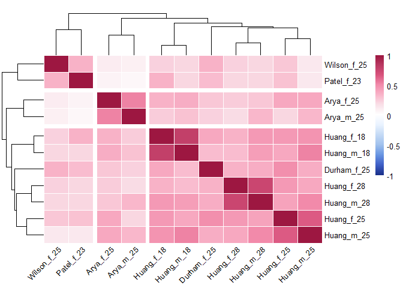

```r
breaksList <- seq(-1, 1, by = 0.02)

#pheatmap(line_e0_corr_matrix, breaks = breaksList,
#main = "", legend_labels = c("-1", "-0.5", "0", "0.5", "Genetic correlation\n"),
#color = colorRampPalette(rev(met.brewer("Benedictus", direction = 1)))(length(breaksList)),
#legend = TRUE, cutree_rows = 3, cutree_cols = 3, angle_col = 45, border_color = "white")

pheatmap(SNP_e0_corr_matrix, breaks = breaksList,
main = "", legend_labels = c("-1", "-0.5", "0", "0.5", "Genetic correlation\n"),
color = colorRampPalette(rev(met.brewer("Benedictus", direction = 1)))(length(breaksList)),
legend = TRUE, cutree_rows = 3, cutree_cols = 3, angle_col = 45, border_color = "white")
```

Now for lifespan equality

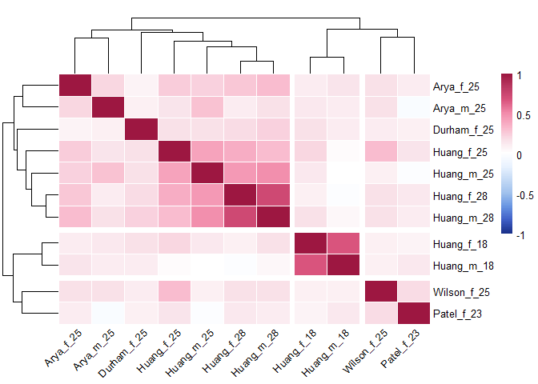

```r
#pheatmap(all_h_corr_matrix, breaks = breaksList,
#main = "", legend_labels = c("-1", "-0.5", "0", "0.5", "Genetic correlation\n"),
#color = colorRampPalette(rev(met.brewer("Benedictus", direction = 1)))(length(breaksList)),
#legend = TRUE, cutree_rows = 3, cutree_cols = 3, angle_col = 45, border_color = "white")

pheatmap(SNP_h_corr_matrix, breaks = breaksList,
main = "", legend_labels = c("-1", "-0.5", "0", "0.5", "Genetic correlation\n"),
color = colorRampPalette(rev(met.brewer("Benedictus", direction = 1)))(length(breaksList)),
legend = TRUE, cutree_rows = 3, cutree_cols = 3, angle_col = 45, border_color = "white")
```

### Calculate meta-analytic test statistics

#### e0, sexes combined

The purpose of this meta-analysis is to search for SNPs that have some effect on ageing, expressed in many different contexts (sexes, temperatures and mating status’).

To conduct CPASSOC for a given SNP, we need a summary statistic from each GWAS. A different number of lines were included in each GWAS, which can cause small differences in the number of SNPs assessed. We therefore prune the list of SNPs to those included in all univariate analyses. After pruning (and previous pruning to remove SNPs in linkage disequilibrium), 220,582 SNPs remain.

```r
Arya_f_l_T <- Arya_f_l_GWAS %>%
  dplyr::select(SNP, T) %>%
  rename(Arya_f = T)

Huang_f_18_l_T <- Huang_f_18_l_GWAS %>%
  dplyr::select(SNP, T) %>%
  rename(Huang_f_18 = T)

Huang_f_25_l_T <- Huang_f_25_l_GWAS %>%
  dplyr::select(SNP, T) %>%
  rename(Huang_f_25 = T)

Huang_f_28_l_T <- Huang_f_28_l_GWAS %>%
  dplyr::select(SNP, T) %>%
  rename(Huang_f_28 = T)

Wilson_f_l_T <- Wilson_f_l_GWAS %>%
  dplyr::select(SNP, T) %>%
  rename(Wilson_f_25  = T)

Durham_f_l_T <- Durham_f_l_GWAS %>%
  dplyr::select(SNP, T) %>%
  rename(Durham_f_25 = T)

Patel_f_l_T <- Patel_f_l_GWAS %>%
  dplyr::select(SNP, T) %>%
  rename(Patel_f_23 = T)

Arya_m_l_T <- Arya_m_l_GWAS %>%
  dplyr::select(SNP, T) %>%
  rename(Arya_m = T)

Huang_m_18_l_T <- Huang_m_18_l_GWAS %>%
  dplyr::select(SNP, T) %>%
  rename(Huang_m_18  = T)

Huang_m_25_l_T <- Huang_m_25_l_GWAS %>%
  dplyr::select(SNP, T) %>%
  rename(Huang_m_25 = T)

Huang_m_28_l_T <- Huang_m_28_l_GWAS %>%
  dplyr::select(SNP, T) %>%
  rename(Huang_m_28  = T)



all_e0_effect_sizes <-
  Arya_f_l_T %>%
  inner_join(Huang_f_18_l_T, by = "SNP") %>%
  inner_join(Huang_f_25_l_T, by = "SNP") %>%
  inner_join(Huang_f_28_l_T, by = "SNP") %>%
  inner_join(Wilson_f_l_T, by = "SNP") %>%
  inner_join(Durham_f_l_T, by = "SNP") %>%
  inner_join(Patel_f_l_T, by = "SNP") %>%
  inner_join(Arya_m_l_T, by = "SNP") %>%
  inner_join(Huang_m_18_l_T, by = "SNP") %>%
  inner_join(Huang_m_25_l_T, by = "SNP") %>%
  inner_join(Huang_m_28_l_T, by = "SNP")


all_e0_effect_sizes_values <-
  all_e0_effect_sizes %>%
  dplyr::select(2:12)

Sample_size_all <- c(165, 183, 186, 177, 161, 176, 193, 165, 183, 186, 177)

if(!file.exists("data/Derived/GWAS_results/all_e0_meta_results.csv")) {

# run the homogeneous effect meta-analysis

S_hom <- SHom(all_e0_effect_sizes_values, Sample_size_all, SNP_e0_corr_matrix)

# calculate meta-p-values and bind the two together with the SNP names

p_S_hom <- pchisq(S_hom, df = 1, ncp = 0, lower.tail = F) %>%
  as_tibble() %>%
  bind_cols(S_hom) %>%
  rename(meta_p_hom = value,
         S_hom = ...2)

# Calculate S_het, an extension of S_hom that improves power when the genetic effect sizes vary for different traits (e.g. if a SNP has a sex or enviornment opposite effect on lifespan)

# estimate parameters of gamma distribution

para <- EstimateGamma(N = 1E4, Sample_size_all, SNP_e0_corr_matrix);

S_het <- SHet(all_e0_effect_sizes_values, Sample_size_all, SNP_e0_corr_matrix)

# obtain P-values of S_Het using the estimated gamma parameters

p_S_het <- pgamma(q = S_het-para[3], shape = para[1], scale = para[2], lower.tail = F) %>%
  as_tibble() %>%
  bind_cols(S_het) %>%
  rename(meta_p_het = value,
         S_het = ...2)


all_e0_meta_results <-
  all_e0_effect_sizes %>%
  bind_cols(p_S_hom,
            p_S_het) # add the unadjusted p values

write_csv(all_e0_meta_results, "data/Derived/GWAS_results/all_e0_meta_results.csv")

} else all_e0_meta_results <- read_csv("data/Derived/GWAS_results/all_e0_meta_results.csv")
```

#### H sexes combined

```r
Arya_f_h_T <- Arya_f_h_GWAS %>%
  dplyr::select(SNP, T) %>%
  rename(Arya_f = T)

Huang_f_18_h_T <- Huang_f_18_h_GWAS %>%
  dplyr::select(SNP, T) %>%
  rename(Huang_f_18 = T)

Huang_f_25_h_T <- Huang_f_25_h_GWAS %>%
  dplyr::select(SNP, T) %>%
  rename(Huang_f_25 = T)

Huang_f_28_h_T <- Huang_f_28_h_GWAS %>%
  dplyr::select(SNP, T) %>%
  rename(Huang_f_28 = T)

Wilson_f_h_T <- Wilson_f_h_GWAS %>%
  dplyr::select(SNP, T) %>%
  rename(Wilson_f_25  = T)

Durham_f_h_T <- Durham_f_h_GWAS %>%
  dplyr::select(SNP, T) %>%
  rename(Durham_f_25 = T)

Patel_f_h_T <- Patel_f_h_GWAS %>%
  dplyr::select(SNP, T) %>%
  rename(Patel_f_23 = T)

Arya_m_h_T <- Arya_m_h_GWAS %>%
  dplyr::select(SNP, T) %>%
  rename(Arya_m = T)

Huang_m_18_h_T <- Huang_m_18_h_GWAS %>%
  dplyr::select(SNP, T) %>%
  rename(Huang_m_18  = T)

Huang_m_25_h_T <- Huang_m_25_h_GWAS %>%
  dplyr::select(SNP, T) %>%
  rename(Huang_m_25 = T)

Huang_m_28_h_T <- Huang_m_28_h_GWAS %>%
  dplyr::select(SNP, T) %>%
  rename(Huang_m_28  = T)


all_h_effect_sizes <-
  Arya_f_h_T %>%
  inner_join(Huang_f_18_h_T, by = "SNP") %>%
  inner_join(Huang_f_25_h_T, by = "SNP") %>%
  inner_join(Huang_f_28_h_T, by = "SNP") %>%
  inner_join(Wilson_f_h_T, by = "SNP") %>%
  inner_join(Durham_f_h_T, by = "SNP") %>%
  inner_join(Patel_f_h_T, by = "SNP") %>%
  inner_join(Arya_m_h_T, by = "SNP") %>%
  inner_join(Huang_m_18_h_T, by = "SNP") %>%
  inner_join(Huang_m_25_h_T, by = "SNP") %>%
  inner_join(Huang_m_28_h_T, by = "SNP")


all_h_effect_sizes_values <-
  all_h_effect_sizes %>%
  dplyr::select(2:12)

if(!file.exists("data/Derived/GWAS_results/all_h_meta_results.csv")) {

S_hom <- SHom(all_h_effect_sizes_values, Sample_size_all, SNP_h_corr_matrix)

# calculate meta-p-values and bind the two together with the SNP names

p_S_hom <- pchisq(S_hom, df = 1, ncp = 0, lower.tail = F) %>%
  as_tibble() %>%
  bind_cols(S_hom) %>%
  rename(meta_p_hom = value,
         S_hom = ...2)

# Calculate S_het, an extension of S_hom that improves power when the genetic effect sizes vary for different traits (probably not such a problem here given all traits we investigate are some version of life expectancy)

# estimate parameters of gamma distribution

para <- EstimateGamma(N = 1E4, Sample_size_all, SNP_h_corr_matrix);

S_het <- SHet(all_h_effect_sizes_values, Sample_size_all, SNP_h_corr_matrix)

# obtain P-values of S_Het using the estimated gamma parameters

p_S_het <- pgamma(q = S_het-para[3], shape = para[1], scale = para[2], lower.tail = F) %>%
  as_tibble() %>%
  bind_cols(S_het) %>%
  rename(meta_p_het = value,
         S_het = ...2)


all_h_meta_results <-
  all_h_effect_sizes %>%
  bind_cols(p_S_hom,
            p_S_het) # add the unadjusted p values

write_csv(all_h_meta_results, "data/Derived/GWAS_results/all_h_meta_results.csv")
} else all_h_meta_results <- read_csv("data/Derived/GWAS_results/all_h_meta_results.csv")
```

### Plot the results

We combine GWAS summary statistics calculated from lifespan data measured across different contexts. It’s possible that some SNPs have G x E interactions that would lead to a heterogeneous effect across phenotypes. We therefore utilise the `S_het` calculated p-values.

First lets show the effect of CPASSOC on the number of variants found to be associated with life expectancy and lifespan equality.

```r
tibble(Analysis = c("CPASSOC", "Univariate", "CPASSOC", "Univariate"),
       Trait = c("Life expectancy", "Life expectancy", "Lifespan equality", "Lifespan equality"),
       `p < 0.05e-05 variants` = c(sum(all_e0_meta_results$meta_p_het < 0.00005),
                                   p_05_SNPs,
                                   sum(all_h_meta_results$meta_p_het < 0.00005),
                                   p_05_SNPs_h),
       `p < 0.05e-08 variants` = c(sum(all_e0_meta_results$meta_p_het < 0.00000005),
                                   sum(e0_table$`p < 0.05e-08 variants`),
                                   sum(all_h_meta_results$meta_p_het < 0.00000005),
                                   sum(h_table$`p < 0.05e-08 variants`)))  %>%
  kable() %>%
  kable_styling()
```

| Analysis | Trait | p < 0.05e-05 variants | p < 0.05e-08 variants |
| --- | --- | --- | --- |
| CPASSOC | Life expectancy | 260 | 47 |
| Univariate | Life expectancy | 160 | 0 |
| CPASSOC | Lifespan equality | 103 | 10 |
| Univariate | Lifespan equality | 144 | 0 |

Now lets build some ‘Manhattan plots’ to show where these significant associations can be found:

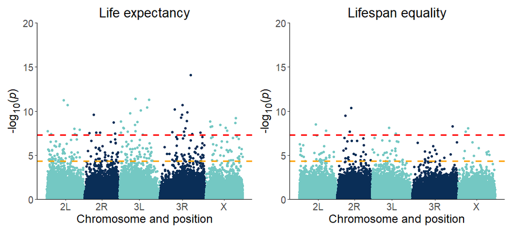

```r
common_SNPs <-
  all_e0_meta_results %>% filter(meta_p_het < 0.00000005) %>%
  inner_join(all_h_meta_results %>% filter(meta_p_het < 0.00000005), by = "SNP") %>%
  mutate(common_SNP = "YES") %>%
  dplyr::select(SNP, common_SNP)

e0_results <-
  all_e0_meta_results %>%
  dplyr::select(SNP, meta_p_hom, meta_p_het) %>%
  rename(P = meta_p_het) %>%
  left_join(common_SNPs) %>%
  mutate(common_SNP = if_else(is.na(common_SNP), "NO", common_SNP))


h_results <-
  all_h_meta_results %>%
  dplyr::select(SNP, meta_p_hom, meta_p_het) %>%
  rename(P = meta_p_het) %>%
  left_join(common_SNPs) %>%
  mutate(common_SNP = if_else(is.na(common_SNP), "NO", common_SNP))

# plot the results using the manhattan plot custom function we defined earlier

e0_het_plot <- build_manhattan_plot(e0_results) +
  labs(title = "Life expectancy") +
  theme(plot.title = element_text(size = 20, hjust = 0.5)) +
  coord_cartesian(ylim = c(0, 20))

h_het_plot <- build_manhattan_plot(h_results) +
  labs(title = "Lifespan equality") +
  theme(plot.title = element_text(size = 20, hjust = 0.5)) +
  coord_cartesian(ylim = c(0, 20))


e0_het_plot + h_het_plot
```

Plot the univariate effect sizes for each of the SNPs associated with life expectancy / lifespan equality at the genome-wide significance threshold (p < $0.05^{-8}$) after CPASSOC.

**Life expectancy**

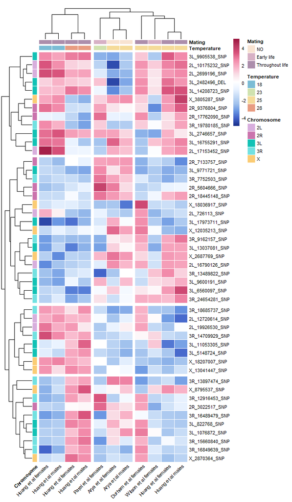

```r
SNP_heatmap_e0 <-
  all_e0_meta_results %>% filter(meta_p_het < 0.00000005) %>%
  arrange(meta_p_het) %>% dplyr::select(1:12)

row_name <- SNP_heatmap_e0$SNP
SNP_heatmap_e0 <- SNP_heatmap_e0 %>% dplyr::select(-SNP) %>% as.matrix()
rownames(SNP_heatmap_e0) <- row_name

breaksList <- seq(-5, 5, by = 0.1)

annotation_SNPs <-
  all_e0_meta_results %>% filter(meta_p_het < 0.00000005) %>% dplyr::select(SNP) %>%
  mutate(Chromosome = case_when(str_detect(SNP, "2L") ~ "2L",
                                str_detect(SNP, "2R") ~ "2R",
                                str_detect(SNP, "3L") ~ "3L",
                                str_detect(SNP, "3R") ~ "3R",
                                str_detect(SNP, "X") ~ "X"))

annotation_studies <-
  tibble(Study = c("Arya_f",
                   "Huang_f_18",
                   "Huang_f_25",
                   "Huang_f_28",
                   "Wilson_f_25",
                   "Durham_f_25",
                   "Patel_f_23",
                   "Arya_m",
                   "Huang_m_18",
                   "Huang_m_25",
                   "Huang_m_28"),
         Temperature = c("25",
                         "18",
                         "25",
                         "28",
                         "25",
                         "25",
                         "23",
                         "25",
                         "18",
                         "25",
                         "28")) %>%
  mutate(Sex = case_when(str_detect(Study, "_f") ~ "Female",
                         .default = "Male"),
         Mating  = case_when(str_detect(Study, "Arya") ~ "NO",
                             str_detect(Study, "Huang") ~ "Throughout life",
                             str_detect(Study, "Wilson") ~ "Early life",
                             str_detect(Study, "Durham") ~ "Throughout life",
                             str_detect(Study, "Patel") ~ "Early life"),
         Author = str_extract(Study, ".*(?=\\_)"),
         Author = str_remove(Author, "_f"),
         Author = str_remove(Author, "_m"))


# create a study annotation column, need this to be a data.frame rather than a tibble for some reason

Study_details <- annotation_studies %>%
  as.data.frame() %>%
  dplyr::select(Study, Temperature, Mating)

my_categories <- data.frame(row.names = Study_details[, 1], Temperature = Study_details[, 2],
                            Mating = Study_details[, 3])

my_colors <- list(Temperature = c("18" = "#7bbcd5", # sailboat colours from pnw
                                  "23" = "#d0e2af",
                                  "25" = "#f5db99",
                                  "28" = "#e89c81"),
                  Mating = c("NO" = "#f8e3d1", # Shuksan from pnw
                             "Early life" = "#d7b1c5",
                             "Throughout life" = "#ac8eab"),
                  Chromosome = c("2L" = "#d8aedd", # lake colours from pnw
                                 "2R" = "#cb74ad",
                                 "3L" = "#11c2b5",
                                 "3R" = "#72e1e1",
                                 "X" = "#fbcc74"))
# create a SNP annotation column

SNP_details <- annotation_SNPs %>%
  as.data.frame()

my_SNP_categories <- data.frame(row.names = SNP_details[, 1], Chromosome = SNP_details[, 2])

my_col_names <- c("Arya et al females", "Huang et al females", "Huang et al females",
                  "Huang et al females", "Wilson et al females", "Durham et al females",
                  "Patel et al females", "Arya et al males", "Huang et al males", "Huang et al males",
                  "Huang et al males")


pheatmap(SNP_heatmap_e0, breaks = breaksList,
         main = "", legend_labels = c("-1", "-0.5", "0", "0.5", "Genetic correlation\n"),
         color = colorRampPalette(rev(met.brewer("Benedictus", direction = 1)))(length(breaksList)),
         legend = TRUE, cutree_rows = 4, cutree_cols = 3,
         angle_col = 45, border_color = "white",
         annotation_col = my_categories, annotation_colors = my_colors, annotation_row = my_SNP_categories,
         fontsize = 8, labels_col = my_col_names)
```

**Lifespan inequality**

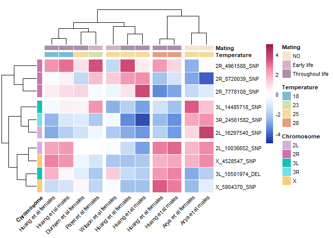

```r
SNP_heatmap_h <-
  all_h_meta_results %>% filter(meta_p_het < 0.00000005) %>%
  arrange(meta_p_het) %>% dplyr::select(1:12)

row_name <- SNP_heatmap_h$SNP
SNP_heatmap_h <- SNP_heatmap_h %>% dplyr::select(-SNP) %>% as.matrix()
rownames(SNP_heatmap_h) = row_name

breaksList <- seq(-5, 5, by = 0.1)

annotation_SNPs_h <-
  all_h_meta_results %>% filter(meta_p_het < 0.00000005) %>% dplyr::select(SNP) %>%
  mutate(Chromosome = case_when(str_detect(SNP, "2L") ~ "2L",
                                str_detect(SNP, "2R") ~ "2R",
                                str_detect(SNP, "3L") ~ "3L",
                                str_detect(SNP, "3R") ~ "3R",
                                str_detect(SNP, "X") ~ "X"))


# create a SNP annotation column

SNP_details_h <- annotation_SNPs_h %>%
  as.data.frame()

my_SNP_categories_h <- data.frame(row.names = SNP_details_h[, 1], Chromosome = SNP_details_h[, 2])

pheatmap(SNP_heatmap_h, breaks = breaksList,
         main = "", legend_labels = c("-1", "-0.5", "0", "0.5", "Genetic correlation\n"),
         color = colorRampPalette(rev(met.brewer("Benedictus", direction = 1)))(length(breaksList)),
         legend = TRUE, cutree_rows = 3, cutree_cols = 4, angle_col = 45, border_color = "white",
         annotation_col = my_categories, annotation_colors = my_colors,
         annotation_row = my_SNP_categories_h,
         fontsize = 8, labels_col = my_col_names)
```

# Analysis of sexually antagonistic effects on ageing

**The intersex genetic correlation**

Lets take a quick look at the intersex-genetic correlations for our metrics in each relevant measurement condition.

```r
Arya_two_sexes_SNPS <-
  left_join(
    Arya_f_l_GWAS %>%
      dplyr::select(1:2) %>%
      rename(Female_e0_effect = BETA),

    Arya_m_l_GWAS %>%
      dplyr::select(1:2) %>%
      rename(Male_e0_effect = BETA)
  ) %>%
  left_join(Arya_f_h_GWAS %>%
              dplyr::select(1:2) %>%
              rename(Female_h_effect = BETA)) %>%
  left_join(Arya_m_h_GWAS %>%
              dplyr::select(1:2) %>%
              rename(Male_h_effect = BETA))

Huang_18_two_sexes_SNPS <-
  left_join(
    Huang_f_18_l_GWAS %>%
      dplyr::select(1:2) %>%
      rename(Female_e0_effect = BETA),

    Huang_m_18_l_GWAS %>%
      dplyr::select(1:2) %>%
      rename(Male_e0_effect = BETA)
  ) %>%
  left_join(Huang_f_18_h_GWAS %>%
              dplyr::select(1:2) %>%
              rename(Female_h_effect = BETA)) %>%
  left_join(Huang_m_18_h_GWAS %>%
              dplyr::select(1:2) %>%
              rename(Male_h_effect = BETA))


Huang_25_two_sexes_SNPS <-
  left_join(
    Huang_f_25_l_GWAS %>%
      dplyr::select(1:2) %>%
      rename(Female_e0_effect = BETA),

    Huang_m_25_l_GWAS %>%
      dplyr::select(1:2) %>%
      rename(Male_e0_effect = BETA)
  ) %>%
  left_join(Huang_f_25_h_GWAS %>%
              dplyr::select(1:2) %>%
              rename(Female_h_effect = BETA)) %>%
  left_join(Huang_m_25_h_GWAS %>%
              dplyr::select(1:2) %>%
              rename(Male_h_effect = BETA))


Huang_28_two_sexes_SNPS <-
  left_join(
    Huang_f_28_l_GWAS %>%
      dplyr::select(1:2) %>%
      rename(Female_e0_effect = BETA),

    Huang_m_28_l_GWAS %>%
      dplyr::select(1:2) %>%
      rename(Male_e0_effect = BETA)
  ) %>%
  left_join(Huang_f_28_h_GWAS %>%
              dplyr::select(1:2) %>%
              rename(Female_h_effect = BETA)) %>%
  left_join(Huang_m_28_h_GWAS %>%
              dplyr::select(1:2) %>%
              rename(Male_h_effect = BETA))
```

Plot the within-treatment intersex-genetic correlations

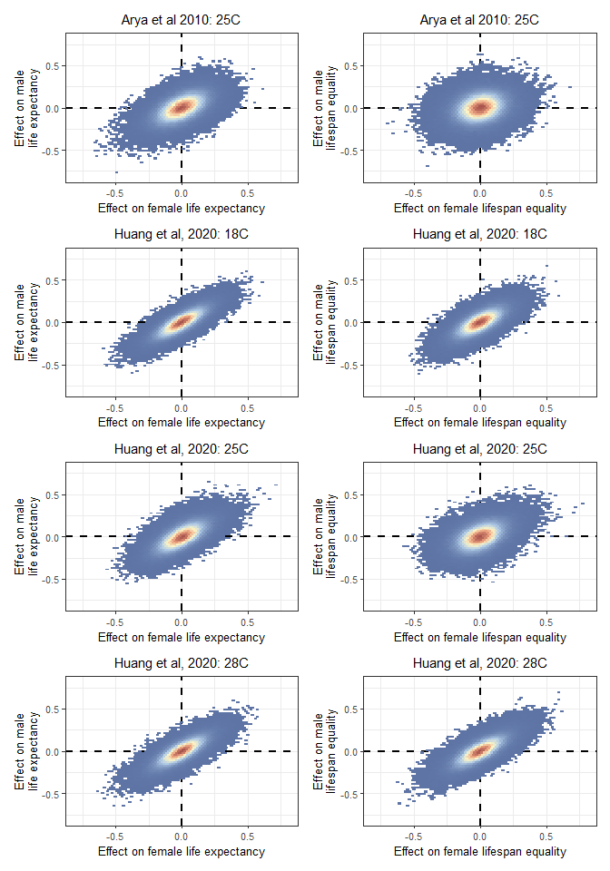

```r
pal <- pnw_palette("Shuksan2", 100)

Arya_e0_sex_plot <-
  Arya_two_sexes_SNPS %>%
  ggplot(aes(x = Female_e0_effect, y = Male_e0_effect )) +
  geom_vline(xintercept = 0, linetype = 2, linewidth = 1) +
  geom_hline(yintercept = 0, linetype = 2, linewidth = 1) +
  stat_binhex(bins = 50) +
  scale_fill_gradientn(colours = pal) +
  #geom_point() +
  #stat_smooth(method = "lm", formula = y ~ x + I(x^2), linewidth = 0.75, colour = "black") +
  coord_cartesian(xlim = c(-0.8, 0.8), ylim = c(-0.8, 0.8)) +
  labs(x = "Effect on female life expectancy",
       y = "Effect on male\nlife expectancy",
       title = "Arya et al 2010: 25C") +
  theme_bw() +
  theme(legend.position = "none",
        text = element_text(size = 10),
        plot.title = element_text(hjust = 0.5, size = 11))

Arya_h_sex_plot <-
  Arya_two_sexes_SNPS %>%
  ggplot(aes(x = Female_h_effect, y = Male_h_effect )) +
  geom_vline(xintercept = 0, linetype = 2, linewidth = 1) +
  geom_hline(yintercept = 0, linetype = 2, linewidth = 1) +
  stat_binhex(bins = 50) +
  scale_fill_gradientn(colours = pal) +
  #geom_point() +
  #stat_smooth(method = "lm", formula = y ~ x + I(x^2), linewidth = 0.75, colour = "black") +
  coord_cartesian(xlim = c(-0.8, 0.8), ylim = c(-0.8, 0.8)) +
  labs(x = "Effect on female lifespan equality",
       y = "Effect on male\nlifespan equality",
       title = "Arya et al 2010: 25C") +
  theme_bw() +
  theme(legend.position = "none",
        text = element_text(size = 10),
        plot.title = element_text(hjust = 0.5, size = 11))

Huang_18_e0_sex_plot <-
  Huang_18_two_sexes_SNPS %>%
  ggplot(aes(x = Female_e0_effect, y = Male_e0_effect )) +
  geom_vline(xintercept = 0, linetype = 2, linewidth = 1) +
  geom_hline(yintercept = 0, linetype = 2, linewidth = 1) +
  stat_binhex(bins = 50) +
  scale_fill_gradientn(colours = pal) +
  #geom_point() +
  #stat_smooth(method = "lm", formula = y ~ x + I(x^2), linewidth = 0.75, colour = "black") +
  coord_cartesian(xlim = c(-0.8, 0.8), ylim = c(-0.8, 0.8)) +
  labs(x = "Effect on female life expectancy",
       y = "Effect on male\nlife expectancy",
       title = "Huang et al, 2020: 18C") +
  theme_bw() +
  theme(legend.position = "none",
        text = element_text(size = 10),
        plot.title = element_text(hjust = 0.5, size = 11))

Huang_18_h_sex_plot <-
  Huang_18_two_sexes_SNPS %>%
  ggplot(aes(x = Female_h_effect, y = Male_h_effect )) +
  geom_vline(xintercept = 0, linetype = 2, linewidth = 1) +
  geom_hline(yintercept = 0, linetype = 2, linewidth = 1) +
  stat_binhex(bins = 50) +
  scale_fill_gradientn(colours = pal) +
  #geom_point() +
  #stat_smooth(method = "lm", formula = y ~ x + I(x^2), linewidth = 0.75, colour = "black") +
  coord_cartesian(xlim = c(-0.8, 0.8), ylim = c(-0.8, 0.8)) +
  labs(x = "Effect on female lifespan equality",
       y = "Effect on male\nlifespan equality",
       title = "Huang et al, 2020: 18C") +
  theme_bw() +
  theme(legend.position = "none",
        text = element_text(size = 10),
        plot.title = element_text(hjust = 0.5, size = 11))

Huang_25_e0_sex_plot <-
  Huang_25_two_sexes_SNPS %>%
  ggplot(aes(x = Female_e0_effect, y = Male_e0_effect )) +
  geom_vline(xintercept = 0, linetype = 2, linewidth = 1) +
  geom_hline(yintercept = 0, linetype = 2, linewidth = 1) +
  stat_binhex(bins = 50) +
  scale_fill_gradientn(colours = pal) +
  #geom_point() +
  #stat_smooth(method = "lm", formula = y ~ x + I(x^2), linewidth = 0.75, colour = "black") +
  coord_cartesian(xlim = c(-0.8, 0.8), ylim = c(-0.8, 0.8)) +
  labs(x = "Effect on female life expectancy",
       y = "Effect on male\nlife expectancy",
       title = "Huang et al, 2020: 25C") +
  theme_bw() +
  theme(legend.position = "none",
        text = element_text(size = 10),
        plot.title = element_text(hjust = 0.5, size = 11))

Huang_25_h_sex_plot <-
  Huang_25_two_sexes_SNPS %>%
  ggplot(aes(x = Female_h_effect, y = Male_h_effect )) +
  geom_vline(xintercept = 0, linetype = 2, linewidth = 1) +
  geom_hline(yintercept = 0, linetype = 2, linewidth = 1) +
  stat_binhex(bins = 50) +
  scale_fill_gradientn(colours = pal) +
  #geom_point() +
  #stat_smooth(method = "lm", formula = y ~ x + I(x^2), linewidth = 0.75, colour = "black") +
  coord_cartesian(xlim = c(-0.8, 0.8), ylim = c(-0.8, 0.8)) +
  labs(x = "Effect on female lifespan equality",
       y = "Effect on male\nlifespan equality",
       title = "Huang et al, 2020: 25C") +
  theme_bw() +
  theme(legend.position = "none",
        text = element_text(size = 10),
        plot.title = element_text(hjust = 0.5, size = 11))

Huang_28_e0_sex_plot <-
  Huang_28_two_sexes_SNPS %>%
  ggplot(aes(x = Female_e0_effect, y = Male_e0_effect )) +
  geom_vline(xintercept = 0, linetype = 2, linewidth = 1) +
  geom_hline(yintercept = 0, linetype = 2, linewidth = 1) +
  stat_binhex(bins = 50) +
  scale_fill_gradientn(colours = pal) +
  #geom_point() +
  #stat_smooth(method = "lm", formula = y ~ x + I(x^2), linewidth = 0.75, colour = "black") +
  coord_cartesian(xlim = c(-0.8, 0.8), ylim = c(-0.8, 0.8)) +
  labs(x = "Effect on female life expectancy",
       y = "Effect on male\nlife expectancy",
       title = "Huang et al, 2020: 28C") +
  theme_bw() +
  theme(legend.position = "none",
        text = element_text(size = 10),
        plot.title = element_text(hjust = 0.5, size = 11))

Huang_28_h_sex_plot <-
  Huang_28_two_sexes_SNPS %>%
  ggplot(aes(x = Female_h_effect, y = Male_h_effect )) +
  geom_vline(xintercept = 0, linetype = 2, linewidth = 1) +
  geom_hline(yintercept = 0, linetype = 2, linewidth = 1) +
  stat_binhex(bins = 50) +
  scale_fill_gradientn(colours = pal) +
  #geom_point() +
  #stat_smooth(method = "lm", formula = y ~ x + I(x^2), linewidth = 0.75, colour = "black") +
  coord_cartesian(xlim = c(-0.8, 0.8), ylim = c(-0.8, 0.8)) +
  labs(x = "Effect on female lifespan equality",
       y = "Effect on male\nlifespan equality",
       title = "Huang et al, 2020: 28C") +
  theme_bw() +
  theme(legend.position = "none",
        text = element_text(size = 10),
        plot.title = element_text(hjust = 0.5, size = 11))

(Arya_e0_sex_plot + Arya_h_sex_plot) /
  (Huang_18_e0_sex_plot + Huang_18_h_sex_plot) /
  (Huang_25_e0_sex_plot + Huang_25_h_sex_plot) /
  (Huang_28_e0_sex_plot + Huang_28_h_sex_plot)
```

**The axis of sexual antagonism**

$$\mathbf{R} = \begin{bmatrix}
\frac{-1}{\sqrt{2}} & \frac{-1}{\sqrt{2}} \\[0.3em]
\frac{-1}{\sqrt{2}} & \frac{1}{\sqrt{2}} \\[0.3em]
\end{bmatrix}$$

```r
rotation_matrix <-
  matrix(c(-1/sqrt(2), -1/sqrt(2), -1/sqrt(2), 1/sqrt(2)),
         nrow = 2)

rotate_axis_function <- function(data_1, data_2, Females, Males, metric){
  left_join(
    data_1 %>% rename(Females = metric),
    data_2 %>% rename(Males = metric)) %>%
    dplyr::select(-line) %>%
    as.matrix() %*% rotation_matrix %>%
    as_tibble() %>%
    rename(SC_axis  = V1,
           SA_axis = V2) %>%
    bind_cols(left_join(
      data_1 %>% rename(Females = metric),
      data_2%>% rename(Males = metric))) %>%
    dplyr::select(line, Females, Males, everything())
}

Arya_l_SA <-
  rotate_axis_function(Arya_f_l, Arya_m_l,
                     Females = "Female_life_expectancy",
                     Males = "Male_life_expectancy",
                     metric = "e0")

Huang_18_l_SA <-
  rotate_axis_function(Huang_f_18_l, Huang_m_18_l,
                     Females = "Female_life_expectancy",
                     Males = "Male_life_expectancy",
                     metric = "e0")

Huang_25_l_SA <-
  rotate_axis_function(Huang_f_25_l, Huang_m_25_l,
                     Females = "Female_life_expectancy",
                     Males = "Male_life_expectancy",
                     metric = "e0")

Huang_28_l_SA <-
  rotate_axis_function(Huang_f_28_l, Huang_m_28_l,
                     Females = "Female_life_expectancy",
                     Males = "Male_life_expectancy",
                     metric = "e0")

# now lifespan equality

Arya_h_SA <-
  rotate_axis_function(Arya_f_h, Arya_m_h,
                     Females = "Female_lifespan_equality",
                     Males = "Male_lifespan_equality",
                     metric = "h")

Huang_18_h_SA <-
  rotate_axis_function(Huang_f_18_h, Huang_m_18_h,
                     Females = "Female_lifespan_equality",
                     Males = "Male_lifespan_equality",
                     metric = "h")

Huang_25_h_SA <-
  rotate_axis_function(Huang_f_25_h, Huang_m_25_h,
                     Females = "Female_lifespan_equality",
                     Males = "Male_lifespan_equality",
                     metric = "h")

Huang_28_h_SA <-
  rotate_axis_function(Huang_f_28_h, Huang_m_28_h,
                     Females = "Female_lifespan_equality",
                     Males = "Male_lifespan_equality",
                     metric = "h")
```

To visualise this transformation lets plot the standardised life expectancy means presented in Arya *et al* 2010

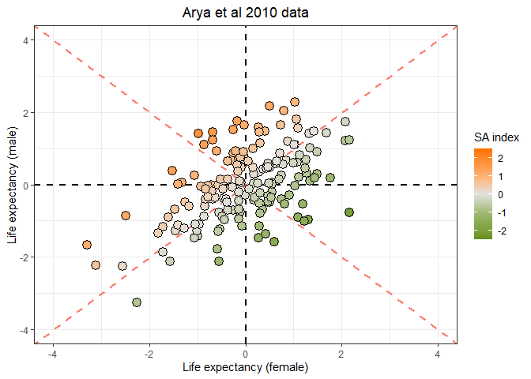

```r
Arya_l_SA %>%
  ggplot(aes(x = Females, y = Males)) +
  geom_vline(xintercept = 0, linetype = 2, linewidth = 1) +
  geom_hline(yintercept = 0, linetype = 2, linewidth = 1) +
  geom_abline(intercept = 0, slope = -1, linewidth = 1, linetype = 2, colour = "salmon") +
  geom_abline(intercept = 0, slope = 1, linewidth = 1, linetype = 2, colour = "salmon") +
  geom_hline(yintercept = 0, linetype = 2, linewidth = 1) +
  geom_point(aes(fill = SA_axis), shape = 21, size = 4) +
  scale_fill_moma_c("Avedon", direction = -1, limits = c(-2.5, 2.5)) +
  coord_cartesian(xlim = c(-4, 4), ylim = c(-4, 4)) +
  labs(fill = "SA index",
       x = "Life expectancy (female)",
       y = "Life expectancy (male)",
       title = "Arya et al 2010 data") +
  theme_bw() +
  theme(plot.title = element_text(hjust = 0.5))
```

Fig XX. Residual line means for female and male life expectancy. Points indicate a single genetic line. The sexual antagonism index ranges from male-beneficial and female-detrimental (orange points) to female-beneficial and male-detrimental (green points). The red dotted lines show the rotation that has been performed to create the antagonism and concordance axis.

**I don’t actually agree that this axis truly represents antagonism. It finds perpendicular departures from the perfect regression, which I guess probably are in part caused by SNPs with sex-opposite effects, but they don’t have to be!**

## Run univariate GWAS

```r
SA_e0_Arya <- prep_for_SA_GWAS(Arya_l_SA)
SA_e0_Huang_18 <- prep_for_SA_GWAS(Huang_18_l_SA)
SA_e0_Huang_25 <- prep_for_SA_GWAS(Huang_25_l_SA)
SA_e0_Huang_28 <- prep_for_SA_GWAS(Huang_28_l_SA)

SA_h_Arya <- prep_for_SA_GWAS(Arya_h_SA)
SA_h_Huang_18 <- prep_for_SA_GWAS(Huang_18_h_SA)
SA_h_Huang_25 <- prep_for_SA_GWAS(Huang_25_h_SA)
SA_h_Huang_28 <- prep_for_SA_GWAS(Huang_28_h_SA)



if(!file.exists("data/Derived/GWAS_results/SA_e0_Arya.tsv.gz")) {
run_GWAS(SA_e0_Arya)
run_GWAS(SA_e0_Huang_18)
run_GWAS(SA_e0_Huang_25)
run_GWAS(SA_e0_Huang_28)
run_GWAS(SA_h_Arya)
run_GWAS(SA_h_Huang_18)
run_GWAS(SA_h_Huang_25)
run_GWAS(SA_h_Huang_28)
}

SA_e0_Arya_GWAS <- read_tsv("data/Derived/GWAS_results/SA_e0_Arya.tsv.gz")
SA_e0_Huang_18_GWAS <- read_tsv("data/Derived/GWAS_results/SA_e0_Huang_18.tsv.gz")
SA_e0_Huang_25_GWAS <- read_tsv("data/Derived/GWAS_results/SA_e0_Huang_25.tsv.gz")
SA_e0_Huang_28_GWAS <- read_tsv("data/Derived/GWAS_results/SA_e0_Huang_28.tsv.gz")

SA_h_Arya_GWAS <- read_tsv("data/Derived/GWAS_results/SA_h_Arya.tsv.gz")
SA_h_Huang_18_GWAS <- read_tsv("data/Derived/GWAS_results/SA_h_Huang_18.tsv.gz")
SA_h_Huang_25_GWAS <- read_tsv("data/Derived/GWAS_results/SA_h_Huang_25.tsv.gz")
SA_h_Huang_28_GWAS <- read_tsv("data/Derived/GWAS_results/SA_h_Huang_28.tsv.gz")
```

How many variants do we find that have notable associations with the SA axis for life expectancy:

```r
# filter down tp sig associations

SA_e0_table <-
bind_rows(
SA_e0_Arya_GWAS %>%
  filter(P < 0.00005) %>%
  transmute(`p < 0.05e-05 variants` = n(),
         `p < 0.05e-08 variants` = nrow(filter(SA_e0_Arya_GWAS, P < 0.00000005))) %>%
  distinct() %>%
  mutate(Study = "Arya et al 2010",
         Temperature = "25",
         `Mating status` = "Virgin") %>%
  dplyr::select(Study, Temperature, `Mating status`, `p < 0.05e-05 variants`, `p < 0.05e-08 variants`),

SA_e0_Huang_18_GWAS %>%
  filter(P < 0.00005) %>%
  transmute(`p < 0.05e-05 variants` = n(),
         `p < 0.05e-08 variants` = nrow(filter(SA_e0_Huang_18_GWAS, P < 0.00000005))) %>%
  distinct() %>%
  mutate(Study = "Huang et al 2020",
         Temperature = "18",
         `Mating status` = "Mated") %>%
  dplyr::select(Study, Temperature, `Mating status`, `p < 0.05e-05 variants`, `p < 0.05e-08 variants`),

SA_e0_Huang_25_GWAS %>%
  filter(P < 0.00005) %>%
  transmute(`p < 0.05e-05 variants` = n(),
         `p < 0.05e-08 variants` = nrow(filter(SA_e0_Huang_25_GWAS, P < 0.00000005))) %>%
  distinct() %>%
  mutate(Study = "Huang et al 2020",
         Temperature = "25",
         `Mating status` = "Mated") %>%
  dplyr::select(Study, Temperature, `Mating status`, `p < 0.05e-05 variants`, `p < 0.05e-08 variants`),

SA_e0_Huang_28_GWAS %>%
  filter(P < 0.00005) %>%
  transmute(`p < 0.05e-05 variants` = n(),
         `p < 0.05e-08 variants` = nrow(filter(SA_e0_Huang_28_GWAS, P < 0.00000005))) %>%
  distinct() %>%
  mutate(Study = "Huang et al 2020",
         Temperature = "28",
         `Mating status` = "Mated") %>%
  dplyr::select(Study, Temperature, `Mating status`, `p < 0.05e-05 variants`, `p < 0.05e-08 variants`))

# how many unique variants have been detected?

SA_p_05_SNPs_e0 <-
  bind_rows(

    SA_e0_Arya_GWAS %>%
      filter(P < 0.00005),

    SA_e0_Huang_18_GWAS %>%
      filter(P < 0.00005),

    SA_e0_Huang_25_GWAS %>%
      filter(P < 0.00005),

    SA_e0_Huang_28_GWAS %>%
      filter(P < 0.00005)) %>%
  distinct(SNP) %>%
  nrow()


SA_e0_table %>%
  add_row(Study = "Totals",
          Temperature = "",
          `Mating status` = "",
          `p < 0.05e-05 variants` = SA_p_05_SNPs_e0,
          `p < 0.05e-08 variants` = sum(SA_e0_table$`p < 0.05e-08 variants`)) %>%
  kable() %>%
  kable_styling()
```

| Study | Temperature | Mating status | p < 0.05e-05 variants | p < 0.05e-08 variants |
| --- | --- | --- | --- | --- |
| Arya et al 2010 | 25 | Virgin | 4 | 0 |
| Huang et al 2020 | 18 | Mated | 9 | 0 |
| Huang et al 2020 | 25 | Mated | 36 | 0 |
| Huang et al 2020 | 28 | Mated | 11 | 0 |
| Totals |  |  | 60 | 0 |

How many variants do we find that have notable associations with the SA axis for lifespan equality:

```r
# filter down tp sig associations

SA_h_table <-
bind_rows(
SA_h_Arya_GWAS %>%
  filter(P < 0.00005) %>%
  transmute(`p < 0.05e-05 variants` = n(),
         `p < 0.05e-08 variants` = nrow(filter(SA_h_Arya_GWAS, P < 0.00000005))) %>%
  distinct() %>%
  mutate(Study = "Arya et al 2010",
         Temperature = "25",
         `Mating status` = "Virgin") %>%
  dplyr::select(Study, Temperature, `Mating status`, `p < 0.05e-05 variants`, `p < 0.05e-08 variants`),

SA_h_Huang_18_GWAS %>%
  filter(P < 0.00005) %>%
  transmute(`p < 0.05e-05 variants` = n(),
         `p < 0.05e-08 variants` = nrow(filter(SA_h_Huang_18_GWAS, P < 0.00000005))) %>%
  distinct() %>%
  mutate(Study = "Huang et al 2020",
         Temperature = "18",
         `Mating status` = "Mated") %>%
  dplyr::select(Study, Temperature, `Mating status`, `p < 0.05e-05 variants`, `p < 0.05e-08 variants`),

SA_h_Huang_25_GWAS %>%
  filter(P < 0.00005) %>%
  transmute(`p < 0.05e-05 variants` = n(),
         `p < 0.05e-08 variants` = nrow(filter(SA_h_Huang_25_GWAS, P < 0.00000005))) %>%
  distinct() %>%
  mutate(Study = "Huang et al 2020",
         Temperature = "25",
         `Mating status` = "Mated") %>%
  dplyr::select(Study, Temperature, `Mating status`, `p < 0.05e-05 variants`, `p < 0.05e-08 variants`),

SA_h_Huang_28_GWAS %>%
  filter(P < 0.00005) %>%
  transmute(`p < 0.05e-05 variants` = n(),
         `p < 0.05e-08 variants` = nrow(filter(SA_h_Huang_28_GWAS, P < 0.00000005))) %>%
  distinct() %>%
  mutate(Study = "Huang et al 2020",
         Temperature = "28",
         `Mating status` = "Mated") %>%
  dplyr::select(Study, Temperature, `Mating status`, `p < 0.05e-05 variants`, `p < 0.05e-08 variants`))

# how many unique variants have been detected?

SA_p_05_SNPs_h <-
  bind_rows(

    SA_h_Arya_GWAS %>%
      filter(P < 0.00005),

    SA_h_Huang_18_GWAS %>%
      filter(P < 0.00005),

    SA_h_Huang_25_GWAS %>%
      filter(P < 0.00005),

    SA_h_Huang_28_GWAS %>%
      filter(P < 0.00005)) %>%
  distinct(SNP) %>%
  nrow()


SA_h_table %>%
  add_row(Study = "Totals",
          Temperature = "",
          `Mating status` = "",
          `p < 0.05e-05 variants` = SA_p_05_SNPs_h,
          `p < 0.05e-08 variants` = sum(SA_h_table$`p < 0.05e-08 variants`)) %>%
  kable() %>%
  kable_styling()
```

| Study | Temperature | Mating status | p < 0.05e-05 variants | p < 0.05e-08 variants |
| --- | --- | --- | --- | --- |
| Arya et al 2010 | 25 | Virgin | 1 | 0 |
| Huang et al 2020 | 18 | Mated | 8 | 0 |
| Huang et al 2020 | 25 | Mated | 18 | 0 |
| Huang et al 2020 | 28 | Mated | 9 | 0 |
| Totals |  |  | 36 | 0 |

## Run CPASSOC

### Generate the genetic correlation matrix

```r
# use the BETA coefficients to build the SNP correlation matrix

SNP_SA_data_e0 <-
  bind_rows(
    SA_e0_Arya_GWAS %>%
      mutate(Study = "Arya", Temperature = 25),
    SA_e0_Huang_18_GWAS %>%
      mutate(Study= "Huang", Temperature= 18),
    SA_e0_Huang_25_GWAS %>%
      mutate(Study= "Huang", Temperature= 25),
    SA_e0_Huang_28_GWAS %>%
      mutate(Study= "Huang", Temperature= 28)) %>%
  dplyr::select(SNP, BETA, Study, Temperature) %>%
  pivot_wider(values_from = BETA, names_from = c(Study, Temperature)) %>%
  dplyr::select(-SNP)

SNP_SA_data_h <-
  bind_rows(
    SA_h_Arya_GWAS %>%
      mutate(Study = "Arya", Temperature = 25),
    SA_h_Huang_18_GWAS %>%
      mutate(Study= "Huang", Temperature= 18),
    SA_h_Huang_25_GWAS %>%
      mutate(Study= "Huang", Temperature= 25),
    SA_h_Huang_28_GWAS %>%
      mutate(Study= "Huang", Temperature= 28)) %>%
  dplyr::select(SNP, BETA, Study, Temperature) %>%
  pivot_wider(values_from = BETA, names_from = c(Study, Temperature)) %>%
  dplyr::select(-SNP)


SNP_SA_e0_corr_matrix <- cor(SNP_SA_data_e0, use = "pairwise.complete.obs", method = "spearman")
SNP_SA_h_corr_matrix <- cor(SNP_SA_data_h, use = "pairwise.complete.obs", method = "spearman")

SA_e0_line_data <-
  bind_rows(Arya_l_SA %>% mutate(Study = "Arya_25"),
            Huang_18_l_SA %>% mutate(Study = "Huang_18"),
            Huang_25_l_SA %>% mutate(Study = "Huang_25"),
            Huang_28_l_SA %>% mutate(Study = "Huang_28")) %>%
  dplyr::select(line, Study, SA_axis) %>%
  pivot_wider(values_from = SA_axis, names_from = Study) %>%
  dplyr::select(-line)

SA_h_line_data <-
  bind_rows(Arya_h_SA %>% mutate(Study = "Arya_25"),
            Huang_18_h_SA %>% mutate(Study = "Huang_18"),
            Huang_25_h_SA %>% mutate(Study = "Huang_25"),
            Huang_28_h_SA %>% mutate(Study = "Huang_28")) %>%
  dplyr::select(line, Study, SA_axis) %>%
  pivot_wider(values_from = SA_axis, names_from = Study) %>%
  dplyr::select(-line)

SA_line_e0_corr_matrix <- cor(SA_e0_line_data, use = "pairwise.complete.obs", method = "spearman")
SA_line_h_corr_matrix <- cor(SA_h_line_data, use = "pairwise.complete.obs", method = "spearman")
```

### Calculate meta-analytic test statistics

#### SA for life expectancy

The purpose of this meta-analysis is to search for SNPs that have sex-specific effects on ageing.

To conduct CPASSOC for a given SNP, we need a summary statistic from each GWAS. A different number of lines were included in each GWAS, which can cause small differences in the number of SNPs assessed. We therefore prune the list of SNPs to those included in all univariate analyses. After pruning (and previous pruning to remove SNPs in linkage disequilibrium), 220,582 SNPs remain.

```r
SA_Arya_l_T <- SA_e0_Arya_GWAS %>%
  dplyr::select(SNP, T) %>%
  rename(Arya = T)

SA_Huang_18_l_T <- SA_e0_Huang_18_GWAS %>%
  dplyr::select(SNP, T) %>%
  rename(Huang_18 = T)

SA_Huang_25_l_T <- SA_e0_Huang_25_GWAS %>%
  dplyr::select(SNP, T) %>%
  rename(Huang_25 = T)

SA_Huang_28_l_T <- SA_e0_Huang_28_GWAS %>%
  dplyr::select(SNP, T) %>%
  rename(Huang_28 = T)

SA_e0_effect_sizes <-
  SA_Arya_l_T %>%
  inner_join(SA_Huang_18_l_T, by = "SNP") %>%
  inner_join(SA_Huang_25_l_T, by = "SNP") %>%
  inner_join(SA_Huang_28_l_T, by = "SNP")


SA_e0_effect_size_values <-
  SA_e0_effect_sizes %>%
  dplyr::select(2:5)

Sample_size_SA <- c(165, 183, 186, 177)

if(!file.exists("data/Derived/GWAS_results/SA_e0_meta_results.csv")) {

# run the homogeneous effect meta-analysis

S_hom <- SHom(SA_e0_effect_size_values, Sample_size_SA, SNP_SA_e0_corr_matrix)

# calculate meta-p-values and bind the two together with the SNP names

p_S_hom <- pchisq(S_hom, df = 1, ncp = 0, lower.tail = F) %>%
  as_tibble() %>%
  bind_cols(S_hom) %>%
  rename(meta_p_hom = value,
         S_hom = ...2)

# Calculate S_het, an extension of S_hom that improves power when the genetic effect sizes vary for different traits (e.g. if a SNP has a sex or enviornment opposite effect on lifespan)

# estimate parameters of gamma distribution

para <- EstimateGamma(N = 1E4, Sample_size_SA, SNP_SA_e0_corr_matrix);

S_het <- SHet(SA_e0_effect_size_values, Sample_size_SA, SNP_SA_e0_corr_matrix)

# obtain P-values of S_Het using the estimated gamma parameters

p_S_het <- pgamma(q = S_het-para[3], shape = para[1], scale = para[2], lower.tail = F) %>%
  as_tibble() %>%
  bind_cols(S_het) %>%
  rename(meta_p_het = value,
         S_het = ...2)


SA_e0_meta_results <-
  SA_e0_effect_sizes %>%
  bind_cols(p_S_hom,
            p_S_het) # add the unadjusted p values

write_csv(SA_e0_meta_results, "data/Derived/GWAS_results/SA_e0_meta_results.csv")

} else SA_e0_meta_results <- read_csv("data/Derived/GWAS_results/SA_e0_meta_results.csv")
```

### SA for lifespan equality

```r
# lifespan equality

SA_Arya_h_T <- SA_h_Arya_GWAS %>%
  dplyr::select(SNP, T) %>%
  rename(Arya = T)

SA_Huang_18_h_T <- SA_h_Huang_18_GWAS %>%
  dplyr::select(SNP, T) %>%
  rename(Huang_18 = T)

SA_Huang_25_h_T <- SA_h_Huang_25_GWAS %>%
  dplyr::select(SNP, T) %>%
  rename(Huang_25 = T)

SA_Huang_28_h_T <- SA_h_Huang_28_GWAS %>%
  dplyr::select(SNP, T) %>%
  rename(Huang_28 = T)

SA_h_effect_sizes <-
  SA_Arya_h_T %>%
  inner_join(SA_Huang_18_h_T, by = "SNP") %>%
  inner_join(SA_Huang_25_h_T, by = "SNP") %>%
  inner_join(SA_Huang_28_h_T, by = "SNP")


SA_h_effect_size_values <-
  SA_h_effect_sizes %>%
  dplyr::select(2:5)

if(!file.exists("data/Derived/GWAS_results/SA_h_meta_results.csv")) {

S_hom <- SHom(SA_h_effect_size_values, Sample_size_SA, SNP_SA_h_corr_matrix)

# calculate meta-p-values and bind the two together with the SNP names

p_S_hom <- pchisq(S_hom, df = 1, ncp = 0, lower.tail = F) %>%
  as_tibble() %>%
  bind_cols(S_hom) %>%
  rename(meta_p_hom = value,
         S_hom = ...2)

# Calculate S_het, an extension of S_hom that improves power when the genetic effect sizes vary for different traits (probably not such a problem here given all traits we investigate are some version of life expectancy)

# estimate parameters of gamma distribution

para <- EstimateGamma(N = 1E4, Sample_size_SA, SNP_SA_h_corr_matrix);

S_het <- SHet(SA_h_effect_size_values, Sample_size_SA, SNP_SA_h_corr_matrix)

# obtain P-values of S_Het using the estimated gamma parameters

p_S_het <- pgamma(q = S_het-para[3], shape = para[1], scale = para[2], lower.tail = F) %>%
  as_tibble() %>%
  bind_cols(S_het) %>%
  rename(meta_p_het = value,
         S_het = ...2)


SA_h_meta_results <-
  SA_h_effect_sizes %>%
  bind_cols(p_S_hom,
            p_S_het) # add the unadjusted p values

write_csv(SA_h_meta_results, "data/Derived/GWAS_results/SA_h_meta_results.csv")
} else SA_h_meta_results <- read_csv("data/Derived/GWAS_results/SA_h_meta_results.csv")
```

### Plot the results

We combine GWAS summary statistics calculated from lifespan data measured across different contexts. It’s possible that some SNPs have G x E interactions that would lead to a heterogeneous effect across phenotypes. We therefore utilise the `S_het` calculated p-values.

First lets show the effect of CPASSOC on the number of variants found to be associated with life expectancy and lifespan equality.

```r
tibble(Analysis = c("CPASSOC", "Univariate", "CPASSOC", "Univariate"),
       Trait = c("Life expectancy", "Life expectancy", "Lifespan equality", "Lifespan equality"),
       `p < 0.05e-05 variants` = c(sum(SA_e0_meta_results$meta_p_het < 0.00005),
                                  SA_p_05_SNPs_e0,
                                  sum(SA_h_meta_results$meta_p_het < 0.00005),
                                  SA_p_05_SNPs_h),
       `p < 0.05e-08 variants` = c(sum(SA_e0_meta_results$meta_p_het < 0.00000005),
                                  sum(SA_e0_table$`p < 0.05e-08 variants`),
                                  sum(SA_h_meta_results$meta_p_het < 0.00000005),
                                  sum(SA_h_table$`p < 0.05e-08 variants`)))  %>%
  kable() %>%
  kable_styling()
```

| Analysis | Trait | p < 0.05e-05 variants | p < 0.05e-08 variants |
| --- | --- | --- | --- |
| CPASSOC | Life expectancy | 32 | 0 |
| Univariate | Life expectancy | 60 | 0 |
| CPASSOC | Lifespan equality | 17 | 0 |
| Univariate | Lifespan equality | 36 | 0 |

```r
#SA_e0_meta_results %>% filter(meta_p_hom < 0.00005) %>%
 # anti_join(SA_p_05_SNPs_e0) %>% arrange(meta_p_hom)
#SA_p_05_SNPs_e0
```

Now lets build some ‘Manhattan plots’ to show where these significant associations can be found:

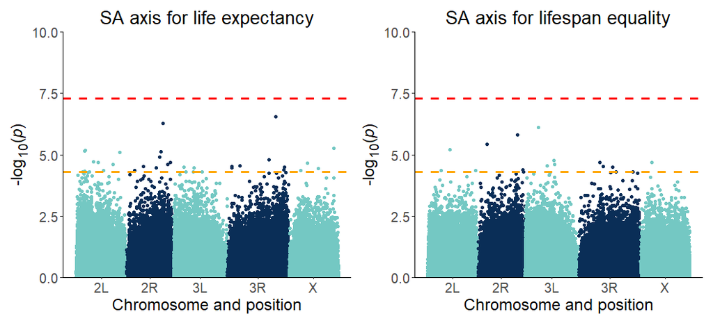

```r
SA_common_SNPs <-
  SA_e0_meta_results %>% filter(meta_p_het < 0.00005) %>%
  inner_join(SA_h_meta_results %>% filter(meta_p_het < 0.00005), by = "SNP") %>%
  mutate(common_SNP = "YES") %>%
  dplyr::select(SNP, common_SNP)

SA_e0_results <-
  SA_e0_meta_results %>%
  dplyr::select(SNP, meta_p_hom, meta_p_het) %>%
  rename(P = meta_p_het) %>%
  left_join(common_SNPs) %>%
  mutate(common_SNP = if_else(is.na(common_SNP), "NO", common_SNP))


SA_h_results <-
  SA_h_meta_results %>%
  dplyr::select(SNP, meta_p_hom, meta_p_het) %>%
  rename(P = meta_p_het) %>%
  left_join(common_SNPs) %>%
  mutate(common_SNP = if_else(is.na(common_SNP), "NO", common_SNP))

# plot the results using the manhattan plot custom function we defined earlier

SA_e0_het_plot <-
  build_manhattan_plot(SA_e0_results) +
  labs(title = "SA axis for life expectancy") +
  theme(plot.title = element_text(size = 20, hjust = 0.5)) +
  coord_cartesian(ylim = c(0, 10))

SA_h_het_plot <-
  build_manhattan_plot(SA_h_results) +
  labs(title = "SA axis for lifespan equality") +
  theme(plot.title = element_text(size = 20, hjust = 0.5)) +
  coord_cartesian(ylim = c(0, 10))


SA_e0_het_plot + SA_h_het_plot
```

# Investigating the rate of ageing and the scaling of mortality risk

## Creating axes of ageing rate and scaling

We’ve shown that perpendicular deviation from the regression of lifespan equality on life expectancy closely corresponds to the rate of ageing (b) parameter in a gompertz mortality model. To identify regions of the genome associated with the rate of ageing, we can calculate a rate of ageing index for each line in each treatment, by once again using rotation matrices. To create this index, we rotate the coordinate system of the life expectancy and lifespan equality plane by $\theta$ degrees, where $\theta$ is the angle between the positive x-axis and the regression of lifespan equality on life expectancy (mean centered and standarised to $\sigma$ = 1).

**Finding the slopes**

```r
Arya_f_model <- brm(h_scaled ~ 1 + e0_scaled,
            prior = c(prior(normal(0, 0.1), class = Intercept),
                      prior(normal(0, 1), class = b),
                      prior(exponential(1), class = sigma)),
            family = gaussian,
            iter = 6000, warmup = 2000,
            control = list(adapt_delta = 0.8, max_treedepth = 10),
            data = Arya_2010_f, chains = 4, cores = 4, file = "Arya_f_slope",
            #backend = "cmdstanr", stan_model_args = list(stanc_options = list("O1")),
            refresh = 400, silent = 0, seed = 1)

Arya_f_slope <-
  as_draws_df(Arya_f_model) %>%
  as_tibble() %>%
  dplyr::select(b_e0_scaled) %>%
  summarise(slope = mean(b_e0_scaled)) %>% pull(slope)

Arya_m_model <- brm(h_scaled ~ 1 + e0_scaled,
            prior = c(prior(normal(0, 0.1), class = Intercept),
                      prior(normal(0, 1), class = b),
                      prior(exponential(1), class = sigma)),
            family = gaussian,
            iter = 6000, warmup = 2000,
            control = list(adapt_delta = 0.8, max_treedepth = 10),
            data = Arya_2010_m, chains = 4, cores = 4, file = "Arya_m_slope",
            #backend = "cmdstanr", stan_model_args = list(stanc_options = list("O1")),
            refresh = 400, silent = 0, seed = 1)

Arya_m_slope <-
  as_draws_df(Arya_m_model) %>%
  as_tibble() %>%
  dplyr::select(b_e0_scaled) %>%
  summarise(slope = mean(b_e0_scaled)) %>% pull(slope)

Huang_f_18_model <- brm(h_scaled ~ 1 + e0_scaled,
            prior = c(prior(normal(0, 0.1), class = Intercept),
                      prior(normal(0, 1), class = b),
                      prior(exponential(1), class = sigma)),
            family = gaussian,
            iter = 6000, warmup = 2000,
            control = list(adapt_delta = 0.8, max_treedepth = 10),
            data = Huang_2020_f_18, chains = 4, cores = 4, file = "Huang_f_18_slope",
            #backend = "cmdstanr", stan_model_args = list(stanc_options = list("O1")),
            refresh = 400, silent = 0, seed = 1)

Huang_f_18_slope <-
  as_draws_df(Huang_f_18_model) %>%
  as_tibble() %>%
  dplyr::select(b_e0_scaled) %>%
  summarise(slope = mean(b_e0_scaled)) %>% pull(slope)

Huang_m_18_model <- brm(h_scaled ~ 1 + e0_scaled,
            prior = c(prior(normal(0, 0.1), class = Intercept),
                      prior(normal(0, 1), class = b),
                      prior(exponential(1), class = sigma)),
            family = gaussian,
            iter = 6000, warmup = 2000,
            control = list(adapt_delta = 0.8, max_treedepth = 10),
            data = Huang_2020_m_18, chains = 4, cores = 4, file = "Huang_m_18_slope",
            #backend = "cmdstanr", stan_model_args = list(stanc_options = list("O1")),
            refresh = 400, silent = 0, seed = 1)

Huang_m_18_slope <-
  as_draws_df(Huang_m_18_model) %>%
  as_tibble() %>%
  dplyr::select(b_e0_scaled) %>%
  summarise(slope = mean(b_e0_scaled)) %>% pull(slope)

Huang_f_25_model <- brm(h_scaled ~ 1 + e0_scaled,
            prior = c(prior(normal(0, 0.1), class = Intercept),
                      prior(normal(0, 1), class = b),
                      prior(exponential(1), class = sigma)),
            family = gaussian,
            iter = 6000, warmup = 2000,
            control = list(adapt_delta = 0.8, max_treedepth = 10),
            data = Huang_2020_f_25, chains = 4, cores = 4, file = "Huang_f_25_slope",
            #backend = "cmdstanr", stan_model_args = list(stanc_options = list("O1")),
            refresh = 400, silent = 0, seed = 1)

Huang_f_25_slope <-
  as_draws_df(Huang_f_25_model) %>%
  as_tibble() %>%
  dplyr::select(b_e0_scaled) %>%
  summarise(slope = mean(b_e0_scaled)) %>% pull(slope)

Huang_m_25_model <- brm(h_scaled ~ 1 + e0_scaled,
            prior = c(prior(normal(0, 0.1), class = Intercept),
                      prior(normal(0, 1), class = b),
                      prior(exponential(1), class = sigma)),
            family = gaussian,
            iter = 6000, warmup = 2000,
            control = list(adapt_delta = 0.8, max_treedepth = 10),
            data = Huang_2020_m_25, chains = 4, cores = 4, file = "Huang_m_25_slope",
            #backend = "cmdstanr", stan_model_args = list(stanc_options = list("O1")),
            refresh = 400, silent = 0, seed = 1)

Huang_m_25_slope <-
  as_draws_df(Huang_m_25_model) %>%
  as_tibble() %>%
  dplyr::select(b_e0_scaled) %>%
  summarise(slope = mean(b_e0_scaled)) %>% pull(slope)

Huang_f_28_model <- brm(h_scaled ~ 1 + e0_scaled,
            prior = c(prior(normal(0, 0.1), class = Intercept),
                      prior(normal(0, 1), class = b),
                      prior(exponential(1), class = sigma)),
            family = gaussian,
            iter = 6000, warmup = 2000,
            control = list(adapt_delta = 0.8, max_treedepth = 10),
            data = Huang_2020_f_28, chains = 4, cores = 4, file = "Huang_f_28_slope",
            #backend = "cmdstanr", stan_model_args = list(stanc_options = list("O1")),
            refresh = 400, silent = 0, seed = 1)

Huang_f_28_slope <-
  as_draws_df(Huang_f_28_model) %>%
  as_tibble() %>%
  dplyr::select(b_e0_scaled) %>%
  summarise(slope = mean(b_e0_scaled)) %>% pull(slope)

Huang_m_28_model <- brm(h_scaled ~ 1 + e0_scaled,
            prior = c(prior(normal(0, 0.1), class = Intercept),
                      prior(normal(0, 1), class = b),
                      prior(exponential(1), class = sigma)),
            family = gaussian,
            iter = 6000, warmup = 2000,
            control = list(adapt_delta = 0.8, max_treedepth = 10),
            data = Huang_2020_m_28, chains = 4, cores = 4, file = "Huang_m_28_slope",
            #backend = "cmdstanr", stan_model_args = list(stanc_options = list("O1")),
            refresh = 400, silent = 0, seed = 1)

Huang_m_28_slope <-
  as_draws_df(Huang_m_28_model) %>%
  as_tibble() %>%
  dplyr::select(b_e0_scaled) %>%
  summarise(slope = mean(b_e0_scaled)) %>% pull(slope)

Wilson_f_model <- brm(h_scaled ~ 1 + e0_scaled,
            prior = c(prior(normal(0, 0.1), class = Intercept),
                      prior(normal(0, 1), class = b),
                      prior(exponential(1), class = sigma)),
            family = gaussian,
            iter = 6000, warmup = 2000,
            control = list(adapt_delta = 0.8, max_treedepth = 10),
            data = Wilson_2020_f, chains = 4, cores = 4, file = "Wilson_f_slope",
            #backend = "cmdstanr", stan_model_args = list(stanc_options = list("O1")),
            refresh = 400, silent = 0, seed = 1)

Wilson_f_slope <-
  as_draws_df(Wilson_f_model) %>%
  as_tibble() %>%
  dplyr::select(b_e0_scaled) %>%
  summarise(slope = mean(b_e0_scaled)) %>% pull(slope)

Durham_f_model <- brm(h_scaled ~ 1 + e0_scaled,
            prior = c(prior(normal(0, 0.1), class = Intercept),
                      prior(normal(0, 1), class = b),
                      prior(exponential(1), class = sigma)),
            family = gaussian,
            iter = 6000, warmup = 2000,
            control = list(adapt_delta = 0.8, max_treedepth = 10),
            data = Durham_2014_f, chains = 4, cores = 4, file = "Durham_f_slope",
            #backend = "cmdstanr", stan_model_args = list(stanc_options = list("O1")),
            refresh = 400, silent = 0, seed = 1)

Durham_f_slope <-
  as_draws_df(Durham_f_model) %>%
  as_tibble() %>%
  dplyr::select(b_e0_scaled) %>%
  summarise(slope = mean(b_e0_scaled)) %>% pull(slope)


Patel_f_model <- brm(h_scaled ~ 1 + e0_scaled,
            prior = c(prior(normal(0, 0.1), class = Intercept),
                      prior(normal(0, 1), class = b),
                      prior(exponential(1), class = sigma)),
            family = gaussian,
            iter = 6000, warmup = 2000,
            control = list(adapt_delta = 0.8, max_treedepth = 10),
            data = Patel_2021_f, chains = 4, cores = 4, file = "Patel_f_slope",
            #backend = "cmdstanr", stan_model_args = list(stanc_options = list("O1")),
            refresh = 400, silent = 0, seed = 1)

Patel_f_slope <-
  as_draws_df(Patel_f_model) %>%
  as_tibble() %>%
  dplyr::select(b_e0_scaled) %>%
  summarise(slope = mean(b_e0_scaled)) %>% pull(slope)
```

With regression coefficients found, we can use the following formula to calculate the angle (in radians) between the mean regression line and the x-axis:

$\theta = tan^{-1}(\beta)$

where $\beta$ is the point estimate of the slope from each model posterior distribution.

```r
Arya_f_angle <- atan(Arya_f_slope)
Arya_m_angle <- atan(Arya_m_slope)
Huang_f_18_angle <- atan(Huang_f_18_slope)
Huang_m_18_angle <- atan(Huang_m_18_slope)
Huang_f_25_angle <- atan(Huang_f_25_slope)
Huang_m_25_angle <- atan(Huang_m_25_slope)
Huang_f_28_angle <- atan(Huang_f_28_slope)
Huang_m_28_angle <- atan(Huang_m_28_slope)
Wilson_f_angle <- atan(Wilson_f_slope)
Durham_f_angle <- atan(Durham_f_slope)
Patel_f_angle <- atan(Patel_f_slope)
```

We then rotate the coordinate system of the life expectancy and lifespan equality plane clockwise by $\theta$:

```r
Arya_2010_f <-
  Arya_2010_f %>%
  mutate(ageing_axis = h_scaled*cos(Arya_f_angle) - e0_scaled*sin(Arya_f_angle),
         scaling_axis = h_scaled*sin(Arya_f_angle) + e0_scaled*cos(Arya_f_angle))

Arya_2010_m <-
  Arya_2010_m %>%
  mutate(ageing_axis = h_scaled*cos(Arya_m_angle) - e0_scaled*sin(Arya_m_angle),
         scaling_axis = h_scaled*sin(Arya_m_angle) + e0_scaled*cos(Arya_m_angle))

Huang_2020_f_18 <-
  Huang_2020_f_18 %>%
  mutate(ageing_axis = h_scaled*cos(Huang_f_18_angle) - e0_scaled*sin(Huang_f_18_angle),
         scaling_axis = h_scaled*sin(Huang_f_18_angle) + e0_scaled*cos(Huang_f_18_angle))

Huang_2020_m_18 <-
  Huang_2020_m_18 %>%
  mutate(ageing_axis = h_scaled*cos(Huang_m_18_angle) - e0_scaled*sin(Huang_m_18_angle),
         scaling_axis = h_scaled*sin(Huang_m_18_angle) + e0_scaled*cos(Huang_m_18_angle))

Huang_2020_f_25 <-
  Huang_2020_f_25 %>%
  mutate(ageing_axis = h_scaled*cos(Huang_f_25_angle) - e0_scaled*sin(Huang_f_25_angle),
         scaling_axis = h_scaled*sin(Huang_f_25_angle) + e0_scaled*cos(Huang_f_25_angle))

Huang_2020_m_25 <-
  Huang_2020_m_25 %>%
  mutate(ageing_axis = h_scaled*cos(Huang_m_25_angle) - e0_scaled*sin(Huang_m_25_angle),
         scaling_axis = h_scaled*sin(Huang_m_25_angle) + e0_scaled*cos(Huang_m_25_angle))

Huang_2020_f_28 <-
  Huang_2020_f_28 %>%
  mutate(ageing_axis = h_scaled*cos(Huang_f_28_angle) - e0_scaled*sin(Huang_f_28_angle),
         scaling_axis = h_scaled*sin(Huang_f_28_angle) + e0_scaled*cos(Huang_f_28_angle))

Huang_2020_m_28 <-
  Huang_2020_m_28 %>%
  mutate(ageing_axis = h_scaled*cos(Huang_m_28_angle) - e0_scaled*sin(Huang_m_28_angle),
         scaling_axis = h_scaled*sin(Huang_m_28_angle) + e0_scaled*cos(Huang_m_28_angle))

Wilson_2020_f <-
  Wilson_2020_f %>%
  mutate(ageing_axis = h_scaled*cos(Wilson_f_angle) - e0_scaled*sin(Wilson_f_angle),
         scaling_axis = h_scaled*sin(Wilson_f_angle) + e0_scaled*cos(Wilson_f_angle))

Durham_2014_f <-
  Durham_2014_f %>%
  mutate(ageing_axis = h_scaled*cos(Durham_f_angle) - e0_scaled*sin(Durham_f_angle),
         scaling_axis = h_scaled*sin(Durham_f_angle) + e0_scaled*cos(Durham_f_angle))

Patel_2021_f <-
  Patel_2021_f %>%
  mutate(ageing_axis = h_scaled*cos(Patel_f_angle) - e0_scaled*sin(Patel_f_angle),
         scaling_axis = h_scaled*sin(Patel_f_angle) + e0_scaled*cos(Patel_f_angle))
```

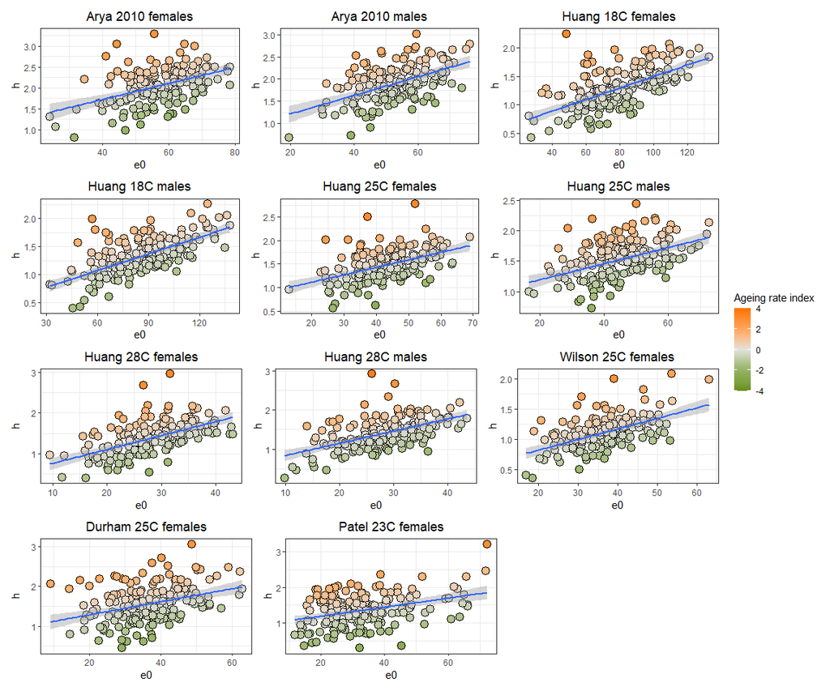

```r
ageing_axis_plot <- function(data, study_title){
data %>%
  ggplot(aes(x = e0, y = h)) +
  geom_point(aes(fill = ageing_axis), shape = 21, size = 4) +
  scale_fill_moma_c("Avedon", direction = -1, limits = c(-4, 4)) +
  geom_smooth(method = "lm") +
  #coord_cartesian(xlim = c(15, 120), ylim = c(0, 3.2)) +
  labs(fill = "Ageing rate index",
       x = "e0",
       y = "h",
       title = study_title) +
  theme_bw() +
  theme(plot.title = element_text(hjust = 0.5))
}

a <- ageing_axis_plot(Arya_2010_f, "Arya 2010 females")
b <- ageing_axis_plot(Arya_2010_m, "Arya 2010 males")
c <- ageing_axis_plot(Huang_2020_f_18, "Huang 18C females")
d <- ageing_axis_plot(Huang_2020_m_18, "Huang 18C males")
e <- ageing_axis_plot(Huang_2020_f_25, "Huang 25C females")
f <- ageing_axis_plot(Huang_2020_m_25, "Huang 25C males")
g <- ageing_axis_plot(Huang_2020_f_28, "Huang 28C females")
h <- ageing_axis_plot(Huang_2020_m_28, "Huang 28C males")
i <- ageing_axis_plot(Wilson_2020_f, "Wilson 25C females")
j <- ageing_axis_plot(Durham_2014_f, "Durham 25C females")
k <- ageing_axis_plot(Patel_2021_f, "Patel 23C females")

(a | b | c) / (d | e | f) / (g | h| i) / (j | k | guide_area()) +
  plot_layout(guides = 'collect')
```

## Run univariate GWAS

```r
Arya_f_ageing <- prep_for_ageing_GWAS(Arya_2010_f)
Arya_m_ageing <- prep_for_ageing_GWAS(Arya_2010_m)
Huang_f_18_ageing <- prep_for_ageing_GWAS(Huang_2020_f_18)
Huang_m_18_ageing <- prep_for_ageing_GWAS(Huang_2020_m_18)
Huang_f_25_ageing <- prep_for_ageing_GWAS(Huang_2020_f_25)
Huang_m_25_ageing <- prep_for_ageing_GWAS(Huang_2020_m_25)
Huang_f_28_ageing <- prep_for_ageing_GWAS(Huang_2020_f_28)
Huang_m_28_ageing <- prep_for_ageing_GWAS(Huang_2020_m_28)
Wilson_f_ageing <- prep_for_ageing_GWAS(Wilson_2020_f)
Durham_f_ageing <- prep_for_ageing_GWAS(Durham_2014_f)
Patel_f_ageing <- prep_for_ageing_GWAS(Patel_2021_f)

Arya_f_scaling <- prep_for_scaling_GWAS(Arya_2010_f)
Arya_m_scaling <- prep_for_scaling_GWAS(Arya_2010_m)
Huang_f_18_scaling <- prep_for_scaling_GWAS(Huang_2020_f_18)
Huang_m_18_scaling <- prep_for_scaling_GWAS(Huang_2020_m_18)
Huang_f_25_scaling <- prep_for_scaling_GWAS(Huang_2020_f_25)
Huang_m_25_scaling <- prep_for_scaling_GWAS(Huang_2020_m_25)
Huang_f_28_scaling <- prep_for_scaling_GWAS(Huang_2020_f_28)
Huang_m_28_scaling <- prep_for_scaling_GWAS(Huang_2020_m_28)
Wilson_f_scaling <- prep_for_scaling_GWAS(Wilson_2020_f)
Durham_f_scaling <- prep_for_scaling_GWAS(Durham_2014_f)
Patel_f_scaling <- prep_for_scaling_GWAS(Patel_2021_f)

if(!file.exists("data/Derived/GWAS_results/Arya_f_ageing.tsv.gz")) {
run_GWAS(Arya_f_ageing)
run_GWAS(Arya_m_ageing)
run_GWAS(Huang_f_18_ageing)
run_GWAS(Huang_m_18_ageing)
run_GWAS(Huang_f_25_ageing)
run_GWAS(Huang_m_25_ageing)
run_GWAS(Huang_f_28_ageing)
run_GWAS(Huang_m_28_ageing)
run_GWAS(Wilson_f_ageing)
run_GWAS(Durham_f_ageing)
run_GWAS(Patel_f_ageing)

run_GWAS(Arya_f_scaling)
run_GWAS(Arya_m_scaling)
run_GWAS(Huang_f_18_scaling)
run_GWAS(Huang_m_18_scaling)
run_GWAS(Huang_f_25_scaling)
run_GWAS(Huang_m_25_scaling)
run_GWAS(Huang_f_28_scaling)
run_GWAS(Huang_m_28_scaling)
run_GWAS(Wilson_f_scaling)
run_GWAS(Durham_f_scaling)
run_GWAS(Patel_f_scaling)
}

Arya_f_ageing_GWAS <- read_tsv("data/Derived/GWAS_results/Arya_f_ageing.tsv.gz")
Arya_m_ageing_GWAS <- read_tsv("data/Derived/GWAS_results/Arya_m_ageing.tsv.gz")
Huang_f_18_ageing_GWAS <- read_tsv("data/Derived/GWAS_results/Huang_f_18_ageing.tsv.gz")
Huang_m_18_ageing_GWAS <- read_tsv("data/Derived/GWAS_results/Huang_m_18_ageing.tsv.gz")
Huang_f_25_ageing_GWAS <- read_tsv("data/Derived/GWAS_results/Huang_f_25_ageing.tsv.gz")
Huang_m_25_ageing_GWAS <- read_tsv("data/Derived/GWAS_results/Huang_m_25_ageing.tsv.gz")
Huang_f_28_ageing_GWAS <- read_tsv("data/Derived/GWAS_results/Huang_f_28_ageing.tsv.gz")
Huang_m_28_ageing_GWAS <- read_tsv("data/Derived/GWAS_results/Huang_m_28_ageing.tsv.gz")
Wilson_f_ageing_GWAS <- read_tsv("data/Derived/GWAS_results/Wilson_f_ageing.tsv.gz")
Durham_f_ageing_GWAS <- read_tsv("data/Derived/GWAS_results/Durham_f_ageing.tsv.gz")
Patel_f_ageing_GWAS <- read_tsv("data/Derived/GWAS_results/Patel_f_ageing.tsv.gz")

Arya_f_scaling_GWAS <- read_tsv("data/Derived/GWAS_results/Arya_f_scaling.tsv.gz")
Arya_m_scaling_GWAS <- read_tsv("data/Derived/GWAS_results/Arya_m_scaling.tsv.gz")
Huang_f_18_scaling_GWAS <- read_tsv("data/Derived/GWAS_results/Huang_f_18_scaling.tsv.gz")
Huang_m_18_scaling_GWAS <- read_tsv("data/Derived/GWAS_results/Huang_m_18_scaling.tsv.gz")
Huang_f_25_scaling_GWAS <- read_tsv("data/Derived/GWAS_results/Huang_f_25_scaling.tsv.gz")
Huang_m_25_scaling_GWAS <- read_tsv("data/Derived/GWAS_results/Huang_m_25_scaling.tsv.gz")
Huang_f_28_scaling_GWAS <- read_tsv("data/Derived/GWAS_results/Huang_f_28_scaling.tsv.gz")
Huang_m_28_scaling_GWAS <- read_tsv("data/Derived/GWAS_results/Huang_m_28_scaling.tsv.gz")
Wilson_f_scaling_GWAS <- read_tsv("data/Derived/GWAS_results/Wilson_f_scaling.tsv.gz")
Durham_f_scaling_GWAS <- read_tsv("data/Derived/GWAS_results/Durham_f_scaling.tsv.gz")
Patel_f_scaling_GWAS <- read_tsv("data/Derived/GWAS_results/Patel_f_scaling.tsv.gz")
```

How many variants do we find that have notable associations with ageing rate?

```r
# filter down tp sig associations

ageing_axis_table <-
bind_rows(
Arya_f_ageing_GWAS %>%
  filter(P < 0.00005) %>%
  transmute(`p < 0.05e-05 variants` = n(),
         `p < 0.05e-08 variants` = nrow(filter(Arya_f_ageing_GWAS, P < 0.00000005))) %>%
  distinct() %>%
  mutate(Study = "Arya et al 2010",
         Sex = "Female",
         Temperature = "25",
         `Mating status` = "Virgin") %>%
  dplyr::select(Study, Sex, Temperature, `Mating status`, `p < 0.05e-05 variants`, `p < 0.05e-08 variants`),

Arya_m_ageing_GWAS %>%
  filter(P < 0.00005) %>%
  transmute(`p < 0.05e-05 variants` = n(),
         `p < 0.05e-08 variants` = nrow(filter(Arya_m_ageing_GWAS, P < 0.00000005))) %>%
  distinct() %>%
  mutate(Study = "Arya et al 2010",
         Sex = "Male",
         Temperature = "25",
         `Mating status` = "Virgin") %>%
  dplyr::select(Study, Sex, Temperature, `Mating status`, `p < 0.05e-05 variants`, `p < 0.05e-08 variants`),

Huang_f_18_ageing_GWAS %>%
  filter(P < 0.00005) %>%
  transmute(`p < 0.05e-05 variants` = n(),
         `p < 0.05e-08 variants` = nrow(filter(Huang_f_18_ageing_GWAS, P < 0.00000005))) %>%
  distinct() %>%
  mutate(Study = "Huang et al 2020",
         Sex = "Female",
         Temperature = "18",
         `Mating status` = "Mated") %>%
  dplyr::select(Study, Sex, Temperature, `Mating status`, `p < 0.05e-05 variants`, `p < 0.05e-08 variants`),

Huang_m_18_ageing_GWAS %>%
  filter(P < 0.00005) %>%
  transmute(`p < 0.05e-05 variants` = n(),
         `p < 0.05e-08 variants` = nrow(filter(Huang_m_18_ageing_GWAS, P < 0.00000005))) %>%
  distinct() %>%
  mutate(Study = "Huang et al 2020",
         Sex = "Male",
         Temperature = "18",
         `Mating status` = "Mated") %>%
  dplyr::select(Study, Sex, Temperature, `Mating status`, `p < 0.05e-05 variants`, `p < 0.05e-08 variants`),

Huang_f_25_ageing_GWAS %>%
  filter(P < 0.00005) %>%
  transmute(`p < 0.05e-05 variants` = n(),
         `p < 0.05e-08 variants` = nrow(filter(Huang_f_25_ageing_GWAS, P < 0.00000005))) %>%
  distinct() %>%
  mutate(Study = "Huang et al 2020",
         Sex = "Female",
         Temperature = "25",
         `Mating status` = "Mated") %>%
  dplyr::select(Study, Sex, Temperature, `Mating status`, `p < 0.05e-05 variants`, `p < 0.05e-08 variants`),

Huang_m_25_ageing_GWAS %>%
  filter(P < 0.00005) %>%
  transmute(`p < 0.05e-05 variants` = n(),
         `p < 0.05e-08 variants` = nrow(filter(Huang_m_25_ageing_GWAS, P < 0.00000005))) %>%
  distinct() %>%
  mutate(Study = "Huang et al 2020",
         Sex = "Male",
         Temperature = "25",
         `Mating status` = "Mated") %>%
  dplyr::select(Study, Sex, Temperature, `Mating status`, `p < 0.05e-05 variants`, `p < 0.05e-08 variants`),

Huang_f_28_ageing_GWAS %>%
  filter(P < 0.00005) %>%
  transmute(`p < 0.05e-05 variants` = n(),
         `p < 0.05e-08 variants` = nrow(filter(Huang_f_28_ageing_GWAS, P < 0.00000005))) %>%
  distinct() %>%
  mutate(Study = "Huang et al 2020",
         Sex = "Female",
         Temperature = "28",
         `Mating status` = "Mated") %>%
  dplyr::select(Study, Sex, Temperature, `Mating status`, `p < 0.05e-05 variants`, `p < 0.05e-08 variants`),

Huang_m_28_ageing_GWAS %>%
  filter(P < 0.00005) %>%
  transmute(`p < 0.05e-05 variants` = n(),
         `p < 0.05e-08 variants` = nrow(filter(Huang_m_28_ageing_GWAS, P < 0.00000005))) %>%
  distinct() %>%
  mutate(Study = "Huang et al 2020",
         Sex = "Male",
         Temperature = "28",
         `Mating status` = "Mated") %>%
  dplyr::select(Study, Sex, Temperature, `Mating status`, `p < 0.05e-05 variants`, `p < 0.05e-08 variants`),

Wilson_f_ageing_GWAS %>%
  filter(P < 0.00005) %>%
  transmute(`p < 0.05e-05 variants` = n(),
         `p < 0.05e-08 variants` = nrow(filter(Wilson_f_ageing_GWAS, P < 0.00000005))) %>%
  distinct() %>%
  mutate(Study = "Wilson et al 2020",
         Sex = "Female",
         Temperature = "25",
         `Mating status` = "Mated") %>%
  dplyr::select(Study, Sex, Temperature, `Mating status`, `p < 0.05e-05 variants`, `p < 0.05e-08 variants`),

Durham_f_ageing_GWAS %>%
  filter(P < 0.00005) %>%
  transmute(`p < 0.05e-05 variants` = n(),
         `p < 0.05e-08 variants` = nrow(filter(Durham_f_ageing_GWAS, P < 0.00000005))) %>%
  distinct() %>%
  mutate(Study = "Durham et al 2014",
         Sex = "Female",
         Temperature = "25",
         `Mating status` = "Mated") %>%
  dplyr::select(Study, Sex, Temperature, `Mating status`, `p < 0.05e-05 variants`, `p < 0.05e-08 variants`),

Patel_f_ageing_GWAS %>%
  filter(P < 0.00005) %>%
  transmute(`p < 0.05e-05 variants` = n(),
         `p < 0.05e-08 variants` = nrow(filter(Patel_f_ageing_GWAS, P < 0.00000005))) %>%
  distinct() %>%
  mutate(Study = "Patel et al 2021",
         Sex = "Female",
         Temperature = "23",
         `Mating status` = "Mated") %>%
  dplyr::select(Study, Sex, Temperature, `Mating status`, `p < 0.05e-05 variants`, `p < 0.05e-08 variants`)
)

# how many unique variants have been detected?

ageing_axis_p_05_SNPs <-
  bind_rows(

    Arya_f_ageing_GWAS %>%
      filter(P < 0.00005),

    Arya_m_ageing_GWAS %>%
      filter(P < 0.00005),

    Huang_f_18_ageing_GWAS %>%
      filter(P < 0.00005),

    Huang_m_18_ageing_GWAS %>%
      filter(P < 0.00005),

    Huang_f_25_ageing_GWAS %>%
      filter(P < 0.00005),

    Huang_m_25_ageing_GWAS %>%
      filter(P < 0.00005),

    Huang_f_28_ageing_GWAS %>%
      filter(P < 0.00005),

    Huang_m_28_ageing_GWAS %>%
      filter(P < 0.00005),

     Wilson_f_ageing_GWAS %>%
      filter(P < 0.00005),

    Durham_f_ageing_GWAS %>%
      filter(P < 0.00005),

    Patel_f_ageing_GWAS %>%
      filter(P < 0.00005)) %>%
  distinct(SNP) %>%
  nrow()


ageing_axis_table %>%
  add_row(Study = "Totals",
          Temperature = "",
          `Mating status` = "",
          `p < 0.05e-05 variants` = ageing_axis_p_05_SNPs,
          `p < 0.05e-08 variants` = sum(ageing_axis_table$`p < 0.05e-08 variants`)) %>%
  kable() %>%
  kable_styling()
```

| Study | Sex | Temperature | Mating status | p < 0.05e-05 variants | p < 0.05e-08 variants |
| --- | --- | --- | --- | --- | --- |
| Arya et al 2010 | Female | 25 | Virgin | 9 | 0 |
| Arya et al 2010 | Male | 25 | Virgin | 10 | 0 |
| Huang et al 2020 | Female | 18 | Mated | 15 | 0 |
| Huang et al 2020 | Male | 18 | Mated | 15 | 0 |
| Huang et al 2020 | Female | 25 | Mated | 29 | 0 |
| Huang et al 2020 | Male | 25 | Mated | 19 | 0 |
| Huang et al 2020 | Female | 28 | Mated | 22 | 0 |
| Huang et al 2020 | Male | 28 | Mated | 24 | 0 |
| Wilson et al 2020 | Female | 25 | Mated | 31 | 0 |
| Durham et al 2014 | Female | 25 | Mated | 4 | 0 |
| Patel et al 2021 | Female | 23 | Mated | 11 | 0 |
| Totals | NA |  |  | 180 | 0 |

What about scaling

```r
# filter down tp sig associations

scaling_axis_table <-
bind_rows(
Arya_f_scaling_GWAS %>%
  filter(P < 0.00005) %>%
  transmute(`p < 0.05e-05 variants` = n(),
         `p < 0.05e-08 variants` = nrow(filter(Arya_f_scaling_GWAS, P < 0.00000005))) %>%
  distinct() %>%
  mutate(Study = "Arya et al 2010",
         Sex = "Female",
         Temperature = "25",
         `Mating status` = "Virgin") %>%
  dplyr::select(Study, Sex, Temperature, `Mating status`, `p < 0.05e-05 variants`, `p < 0.05e-08 variants`),

Arya_m_scaling_GWAS %>%
  filter(P < 0.00005) %>%
  transmute(`p < 0.05e-05 variants` = n(),
         `p < 0.05e-08 variants` = nrow(filter(Arya_m_scaling_GWAS, P < 0.00000005))) %>%
  distinct() %>%
  mutate(Study = "Arya et al 2010",
         Sex = "Male",
         Temperature = "25",
         `Mating status` = "Virgin") %>%
  dplyr::select(Study, Sex, Temperature, `Mating status`, `p < 0.05e-05 variants`, `p < 0.05e-08 variants`),

Huang_f_18_scaling_GWAS %>%
  filter(P < 0.00005) %>%
  transmute(`p < 0.05e-05 variants` = n(),
         `p < 0.05e-08 variants` = nrow(filter(Huang_f_18_scaling_GWAS, P < 0.00000005))) %>%
  distinct() %>%
  mutate(Study = "Huang et al 2020",
         Sex = "Female",
         Temperature = "18",
         `Mating status` = "Mated") %>%
  dplyr::select(Study, Sex, Temperature, `Mating status`, `p < 0.05e-05 variants`, `p < 0.05e-08 variants`),

Huang_m_18_scaling_GWAS %>%
  filter(P < 0.00005) %>%
  transmute(`p < 0.05e-05 variants` = n(),
         `p < 0.05e-08 variants` = nrow(filter(Huang_m_18_scaling_GWAS, P < 0.00000005))) %>%
  distinct() %>%
  mutate(Study = "Huang et al 2020",
         Sex = "Male",
         Temperature = "18",
         `Mating status` = "Mated") %>%
  dplyr::select(Study, Sex, Temperature, `Mating status`, `p < 0.05e-05 variants`, `p < 0.05e-08 variants`),

Huang_f_25_scaling_GWAS %>%
  filter(P < 0.00005) %>%
  transmute(`p < 0.05e-05 variants` = n(),
         `p < 0.05e-08 variants` = nrow(filter(Huang_f_25_scaling_GWAS, P < 0.00000005))) %>%
  distinct() %>%
  mutate(Study = "Huang et al 2020",
         Sex = "Female",
         Temperature = "25",
         `Mating status` = "Mated") %>%
  dplyr::select(Study, Sex, Temperature, `Mating status`, `p < 0.05e-05 variants`, `p < 0.05e-08 variants`),

Huang_m_25_scaling_GWAS %>%
  filter(P < 0.00005) %>%
  transmute(`p < 0.05e-05 variants` = n(),
         `p < 0.05e-08 variants` = nrow(filter(Huang_m_25_scaling_GWAS, P < 0.00000005))) %>%
  distinct() %>%
  mutate(Study = "Huang et al 2020",
         Sex = "Male",
         Temperature = "25",
         `Mating status` = "Mated") %>%
  dplyr::select(Study, Sex, Temperature, `Mating status`, `p < 0.05e-05 variants`, `p < 0.05e-08 variants`),

Huang_f_28_scaling_GWAS %>%
  filter(P < 0.00005) %>%
  transmute(`p < 0.05e-05 variants` = n(),
         `p < 0.05e-08 variants` = nrow(filter(Huang_f_28_scaling_GWAS, P < 0.00000005))) %>%
  distinct() %>%
  mutate(Study = "Huang et al 2020",
         Sex = "Female",
         Temperature = "28",
         `Mating status` = "Mated") %>%
  dplyr::select(Study, Sex, Temperature, `Mating status`, `p < 0.05e-05 variants`, `p < 0.05e-08 variants`),

Huang_m_28_scaling_GWAS %>%
  filter(P < 0.00005) %>%
  transmute(`p < 0.05e-05 variants` = n(),
         `p < 0.05e-08 variants` = nrow(filter(Huang_m_28_scaling_GWAS, P < 0.00000005))) %>%
  distinct() %>%
  mutate(Study = "Huang et al 2020",
         Sex = "Male",
         Temperature = "28",
         `Mating status` = "Mated") %>%
  dplyr::select(Study, Sex, Temperature, `Mating status`, `p < 0.05e-05 variants`, `p < 0.05e-08 variants`),

Wilson_f_scaling_GWAS %>%
  filter(P < 0.00005) %>%
  transmute(`p < 0.05e-05 variants` = n(),
         `p < 0.05e-08 variants` = nrow(filter(Wilson_f_scaling_GWAS, P < 0.00000005))) %>%
  distinct() %>%
  mutate(Study = "Wilson et al 2020",
         Sex = "Female",
         Temperature = "25",
         `Mating status` = "Mated") %>%
  dplyr::select(Study, Sex, Temperature, `Mating status`, `p < 0.05e-05 variants`, `p < 0.05e-08 variants`),

Durham_f_scaling_GWAS %>%
  filter(P < 0.00005) %>%
  transmute(`p < 0.05e-05 variants` = n(),
         `p < 0.05e-08 variants` = nrow(filter(Durham_f_scaling_GWAS, P < 0.00000005))) %>%
  distinct() %>%
  mutate(Study = "Durham et al 2014",
         Sex = "Female",
         Temperature = "25",
         `Mating status` = "Mated") %>%
  dplyr::select(Study, Sex, Temperature, `Mating status`, `p < 0.05e-05 variants`, `p < 0.05e-08 variants`),

Patel_f_scaling_GWAS %>%
  filter(P < 0.00005) %>%
  transmute(`p < 0.05e-05 variants` = n(),
         `p < 0.05e-08 variants` = nrow(filter(Patel_f_scaling_GWAS, P < 0.00000005))) %>%
  distinct() %>%
  mutate(Study = "Patel et al 2021",
         Sex = "Female",
         Temperature = "23",
         `Mating status` = "Mated") %>%
  dplyr::select(Study, Sex, Temperature, `Mating status`, `p < 0.05e-05 variants`, `p < 0.05e-08 variants`)
)

# how many unique variants have been detected?

scaling_axis_p_05_SNPs <-
  bind_rows(

    Arya_f_scaling_GWAS %>%
      filter(P < 0.00005),

    Arya_m_scaling_GWAS %>%
      filter(P < 0.00005),

    Huang_f_18_scaling_GWAS %>%
      filter(P < 0.00005),

    Huang_m_18_scaling_GWAS %>%
      filter(P < 0.00005),

    Huang_f_25_scaling_GWAS %>%
      filter(P < 0.00005),

    Huang_m_25_scaling_GWAS %>%
      filter(P < 0.00005),

    Huang_f_28_scaling_GWAS %>%
      filter(P < 0.00005),

    Huang_m_28_scaling_GWAS %>%
      filter(P < 0.00005),

     Wilson_f_scaling_GWAS %>%
      filter(P < 0.00005),

    Durham_f_scaling_GWAS %>%
      filter(P < 0.00005),

    Patel_f_scaling_GWAS %>%
      filter(P < 0.00005)) %>%
  distinct(SNP) %>%
  nrow()


scaling_axis_table %>%
  add_row(Study = "Totals",
          Temperature = "",
          `Mating status` = "",
          `p < 0.05e-05 variants` = scaling_axis_p_05_SNPs,
          `p < 0.05e-08 variants` = sum(scaling_axis_table$`p < 0.05e-08 variants`)) %>%
  kable() %>%
  kable_styling()
```

| Study | Sex | Temperature | Mating status | p < 0.05e-05 variants | p < 0.05e-08 variants |
| --- | --- | --- | --- | --- | --- |
| Arya et al 2010 | Female | 25 | Virgin | 19 | 0 |
| Arya et al 2010 | Male | 25 | Virgin | 16 | 0 |
| Huang et al 2020 | Female | 18 | Mated | 12 | 0 |
| Huang et al 2020 | Male | 18 | Mated | 10 | 0 |
| Huang et al 2020 | Female | 25 | Mated | 20 | 0 |
| Huang et al 2020 | Male | 25 | Mated | 18 | 0 |
| Huang et al 2020 | Female | 28 | Mated | 23 | 0 |
| Huang et al 2020 | Male | 28 | Mated | 18 | 0 |
| Wilson et al 2020 | Female | 25 | Mated | 8 | 0 |
| Durham et al 2014 | Female | 25 | Mated | 18 | 0 |
| Patel et al 2021 | Female | 23 | Mated | 27 | 0 |
| Totals | NA |  |  | 187 | 0 |

## Run CPASSOC

### Generate the genetic correlation matrix

Using SNP effect sizes, we calculate the genetic correlations between 1) rates of ageing and 2) scaling of mortality, measured in different environments.

```r
# use the BETA coefficients to build the SNP correlation matrix for the rate of ageing

SNP_ageing_axis_data <-
 bind_rows(
    Arya_f_ageing_GWAS %>%
      mutate(Study = "Arya", Temperature = 25, Sex = "Female"),

    Arya_m_ageing_GWAS %>%
      mutate(Study = "Arya", Temperature = 25, Sex = "Male"),

    Huang_f_18_ageing_GWAS %>%
      mutate(Study = "Huang", Temperature = 18, Sex = "Female"),

    Huang_m_18_ageing_GWAS %>%
      mutate(Study = "Huang", Temperature = 18, Sex = "Male"),

    Huang_f_25_ageing_GWAS %>%
      mutate(Study = "Huang", Temperature = 25, Sex = "Female"),

    Huang_m_25_ageing_GWAS %>%
      mutate(Study = "Huang", Temperature = 25, Sex = "Male"),

    Huang_f_28_ageing_GWAS %>%
      mutate(Study = "Huang", Temperature = 28, Sex = "Female"),

    Huang_m_28_ageing_GWAS %>%
      mutate(Study = "Huang", Temperature = 28, Sex = "Male"),

     Wilson_f_ageing_GWAS %>%
      mutate(Study = "Wilson", Temperature = 25, Sex = "Female"),

    Durham_f_ageing_GWAS %>%
      mutate(Study = "Durham", Temperature = 25, Sex = "Female"),

    Patel_f_ageing_GWAS %>%
      mutate(Study = "Patel", Temperature = 23, Sex = "Female")) %>%
  dplyr::select(SNP, BETA, Study, Temperature, Sex) %>%
  pivot_wider(values_from = BETA, names_from = c(Study, Temperature, Sex)) %>%
  dplyr::select(-SNP)


SNP_ageing_axis_corr_matrix <- cor(SNP_ageing_axis_data, use = "pairwise.complete.obs", method = "spearman")

# use the BETA coefficients to build the SNP correlation matrix for scaling

SNP_scaling_axis_data <-
 bind_rows(
    Arya_f_scaling_GWAS %>%
      mutate(Study = "Arya", Temperature = 25, Sex = "Female"),

    Arya_m_scaling_GWAS %>%
      mutate(Study = "Arya", Temperature = 25, Sex = "Male"),

    Huang_f_18_scaling_GWAS %>%
      mutate(Study = "Huang", Temperature = 18, Sex = "Female"),

    Huang_m_18_scaling_GWAS %>%
      mutate(Study = "Huang", Temperature = 18, Sex = "Male"),

    Huang_f_25_scaling_GWAS %>%
      mutate(Study = "Huang", Temperature = 25, Sex = "Female"),

    Huang_m_25_scaling_GWAS %>%
      mutate(Study = "Huang", Temperature = 25, Sex = "Male"),

    Huang_f_28_scaling_GWAS %>%
      mutate(Study = "Huang", Temperature = 28, Sex = "Female"),

    Huang_m_28_scaling_GWAS %>%
      mutate(Study = "Huang", Temperature = 28, Sex = "Male"),

     Wilson_f_scaling_GWAS %>%
      mutate(Study = "Wilson", Temperature = 25, Sex = "Female"),

    Durham_f_scaling_GWAS %>%
      mutate(Study = "Durham", Temperature = 25, Sex = "Female"),

    Patel_f_scaling_GWAS %>%
      mutate(Study = "Patel", Temperature = 23, Sex = "Female")) %>%
  dplyr::select(SNP, BETA, Study, Temperature, Sex) %>%
  pivot_wider(values_from = BETA, names_from = c(Study, Temperature, Sex)) %>%
  dplyr::select(-SNP)


SNP_scaling_axis_corr_matrix <- cor(SNP_scaling_axis_data, use = "pairwise.complete.obs", method = "spearman")
```

### Calculate meta-analytic test statistics

The purpose of these meta-analyses is to search for SNPs that affect 1) the rate of ageing and 2) the scaling of the risk of mortality.

To conduct CPASSOC for a given SNP, we need a summary statistic from each GWAS. A different number of lines were included in each GWAS, which can cause small differences in the number of SNPs assessed. We therefore prune the list of SNPs to those included in all univariate analyses. After pruning (and previous pruning to remove SNPs in linkage disequilibrium), 220,582 SNPs remain.

**Run CPASSOC for the rate of ageing**

```r
# rate of ageing

ageing_axis_Arya_f_T <-
  Arya_f_ageing_GWAS %>%
  dplyr::select(SNP, T) %>%
  rename(Arya_f = T)

ageing_axis_Arya_m_T <-
  Arya_m_ageing_GWAS %>%
  dplyr::select(SNP, T) %>%
  rename(Arya_m = T)

ageing_axis_Huang_f_18_T <-
  Huang_f_18_ageing_GWAS %>%
  dplyr::select(SNP, T) %>%
  rename(Huang_f_18 = T)

ageing_axis_Huang_m_18_T <-
  Huang_m_18_ageing_GWAS %>%
  dplyr::select(SNP, T) %>%
  rename(Huang_m_18 = T)

ageing_axis_Huang_f_25_T <-
  Huang_f_25_ageing_GWAS %>%
  dplyr::select(SNP, T) %>%
  rename(Huang_f_25 = T)

ageing_axis_Huang_m_25_T <-
  Huang_m_25_ageing_GWAS %>%
  dplyr::select(SNP, T) %>%
  rename(Huang_m_25 = T)

ageing_axis_Huang_f_28_T <-
  Huang_f_28_ageing_GWAS %>%
  dplyr::select(SNP, T) %>%
  rename(Huang_f_28 = T)

ageing_axis_Huang_m_28_T <-
  Huang_m_28_ageing_GWAS %>%
  dplyr::select(SNP, T) %>%
  rename(Huang_m_28 = T)

ageing_axis_Wilson_f_T <-
  Wilson_f_ageing_GWAS %>%
  dplyr::select(SNP, T) %>%
  rename(Wilson_f = T)

ageing_axis_Durham_f_T <-
  Durham_f_ageing_GWAS %>%
  dplyr::select(SNP, T) %>%
  rename(Durham_f = T)

ageing_axis_Patel_f_T <-
  Patel_f_ageing_GWAS %>%
  dplyr::select(SNP, T) %>%
  rename(Patel_f = T)


ageing_axis_effect_sizes <-
  ageing_axis_Arya_f_T %>%
  inner_join(ageing_axis_Arya_m_T, by = "SNP") %>%
  inner_join(ageing_axis_Huang_f_18_T, by = "SNP") %>%
  inner_join(ageing_axis_Huang_m_18_T, by = "SNP") %>%
  inner_join(ageing_axis_Huang_f_25_T, by = "SNP") %>%
  inner_join(ageing_axis_Huang_m_25_T, by = "SNP") %>%
  inner_join(ageing_axis_Huang_f_28_T, by = "SNP") %>%
  inner_join(ageing_axis_Huang_m_28_T, by = "SNP") %>%
  inner_join(ageing_axis_Wilson_f_T, by = "SNP") %>%
  inner_join(ageing_axis_Durham_f_T, by = "SNP") %>%
  inner_join(ageing_axis_Patel_f_T, by = "SNP")


ageing_axis_effect_size_values <-
  ageing_axis_effect_sizes %>%
  dplyr::select(2:12)

Sample_size_ageing_axis <- c(165, 165, 183, 183, 186, 186, 177, 177, 161, 176, 193)

if(!file.exists("data/Derived/GWAS_results/ageing_axis_meta_results.csv")) {

# run the homogeneous effect meta-analysis

S_hom <- SHom(ageing_axis_effect_size_values, Sample_size_ageing_axis, SNP_ageing_axis_corr_matrix)

# calculate meta-p-values and bind the two together with the SNP names

p_S_hom <- pchisq(S_hom, df = 1, ncp = 0, lower.tail = F) %>%
  as_tibble() %>%
  bind_cols(S_hom) %>%
  rename(meta_p_hom = value,
         S_hom = ...2)

# Calculate S_het, an extension of S_hom that improves power when the genetic effect sizes vary for different traits (e.g. if a SNP has a sex or enviornment opposite effect on lifespan)

# estimate parameters of gamma distribution

para <- EstimateGamma(N = 1E4, Sample_size_ageing_axis, SNP_ageing_axis_corr_matrix);

S_het <- SHet(ageing_axis_effect_size_values, Sample_size_ageing_axis, SNP_ageing_axis_corr_matrix)

# obtain P-values of S_Het using the estimated gamma parameters

p_S_het <- pgamma(q = S_het-para[3], shape = para[1], scale = para[2], lower.tail = F) %>%
  as_tibble() %>%
  bind_cols(S_het) %>%
  rename(meta_p_het = value,
         S_het = ...2)


ageing_axis_meta_results <-
  ageing_axis_effect_sizes %>%
  bind_cols(p_S_hom,
            p_S_het) # add the unadjusted p values

write_csv(ageing_axis_meta_results, "data/Derived/GWAS_results/ageing_axis_meta_results.csv")

} else ageing_axis_meta_results <- read_csv("data/Derived/GWAS_results/ageing_axis_meta_results.csv")
```

**Run CPASSOC for the scaling of mortality risk**

```r
# scaling

scaling_axis_Arya_f_T <-
  Arya_f_scaling_GWAS %>%
  dplyr::select(SNP, T) %>%
  rename(Arya_f = T)

scaling_axis_Arya_m_T <-
  Arya_m_scaling_GWAS %>%
  dplyr::select(SNP, T) %>%
  rename(Arya_m = T)

scaling_axis_Huang_f_18_T <-
  Huang_f_18_scaling_GWAS %>%
  dplyr::select(SNP, T) %>%
  rename(Huang_f_18 = T)

scaling_axis_Huang_m_18_T <-
  Huang_m_18_scaling_GWAS %>%
  dplyr::select(SNP, T) %>%
  rename(Huang_m_18 = T)

scaling_axis_Huang_f_25_T <-
  Huang_f_25_scaling_GWAS %>%
  dplyr::select(SNP, T) %>%
  rename(Huang_f_25 = T)

scaling_axis_Huang_m_25_T <-
  Huang_m_25_scaling_GWAS %>%
  dplyr::select(SNP, T) %>%
  rename(Huang_m_25 = T)

scaling_axis_Huang_f_28_T <-
  Huang_f_28_scaling_GWAS %>%
  dplyr::select(SNP, T) %>%
  rename(Huang_f_28 = T)

scaling_axis_Huang_m_28_T <-
  Huang_m_28_scaling_GWAS %>%
  dplyr::select(SNP, T) %>%
  rename(Huang_m_28 = T)

scaling_axis_Wilson_f_T <-
  Wilson_f_scaling_GWAS %>%
  dplyr::select(SNP, T) %>%
  rename(Wilson_f = T)

scaling_axis_Durham_f_T <-
  Durham_f_scaling_GWAS %>%
  dplyr::select(SNP, T) %>%
  rename(Durham_f = T)

scaling_axis_Patel_f_T <-
  Patel_f_scaling_GWAS %>%
  dplyr::select(SNP, T) %>%
  rename(Patel_f = T)


scaling_axis_effect_sizes <-
  scaling_axis_Arya_f_T %>%
  inner_join(scaling_axis_Arya_m_T, by = "SNP") %>%
  inner_join(scaling_axis_Huang_f_18_T, by = "SNP") %>%
  inner_join(scaling_axis_Huang_m_18_T, by = "SNP") %>%
  inner_join(scaling_axis_Huang_f_25_T, by = "SNP") %>%
  inner_join(scaling_axis_Huang_m_25_T, by = "SNP") %>%
  inner_join(scaling_axis_Huang_f_28_T, by = "SNP") %>%
  inner_join(scaling_axis_Huang_m_28_T, by = "SNP") %>%
  inner_join(scaling_axis_Wilson_f_T, by = "SNP") %>%
  inner_join(scaling_axis_Durham_f_T, by = "SNP") %>%
  inner_join(scaling_axis_Patel_f_T, by = "SNP")


scaling_axis_effect_size_values <-
  scaling_axis_effect_sizes %>%
  dplyr::select(2:12)

Sample_size_scaling_axis <- c(165, 165, 183, 183, 186, 186, 177, 177, 161, 176, 193)

if(!file.exists("data/Derived/GWAS_results/scaling_axis_meta_results.csv")) {

# run the homogeneous effect meta-analysis

S_hom <- SHom(scaling_axis_effect_size_values, Sample_size_scaling_axis, SNP_scaling_axis_corr_matrix)

# calculate meta-p-values and bind the two together with the SNP names

p_S_hom <- pchisq(S_hom, df = 1, ncp = 0, lower.tail = F) %>%
  as_tibble() %>%
  bind_cols(S_hom) %>%
  rename(meta_p_hom = value,
         S_hom = ...2)

# Calculate S_het, an extension of S_hom that improves power when the genetic effect sizes vary for different traits (e.g. if a SNP has a sex or enviornment opposite effect on lifespan)

# estimate parameters of gamma distribution

para <- EstimateGamma(N = 1E4, Sample_size_scaling_axis, SNP_scaling_axis_corr_matrix);

S_het <- SHet(scaling_axis_effect_size_values, Sample_size_scaling_axis, SNP_scaling_axis_corr_matrix)

# obtain P-values of S_Het using the estimated gamma parameters

p_S_het <- pgamma(q = S_het-para[3], shape = para[1], scale = para[2], lower.tail = F) %>%
  as_tibble() %>%
  bind_cols(S_het) %>%
  rename(meta_p_het = value,
         S_het = ...2)


scaling_axis_meta_results <-
  scaling_axis_effect_sizes %>%
  bind_cols(p_S_hom,
            p_S_het) # add the unadjusted p values

write_csv(scaling_axis_meta_results, "data/Derived/GWAS_results/scaling_axis_meta_results.csv")

} else scaling_axis_meta_results <- read_csv("data/Derived/GWAS_results/scaling_axis_meta_results.csv")
```

### Plot the results

We combine GWAS summary statistics calculated from ageing and scaling axis data measured across different contexts. It’s possible that some SNPs have G x E interactions that would lead to a heterogeneous effect across phenotypes. We therefore utilise the `S_het` calculated p-values.

First lets show the effect of CPASSOC on the number of variants found to be associated with the rate of ageing and the scaling of mortality risk.

**Table XX**. Genotype to phenotype associations detected by univariate GWAS, for the ageing rate and scaling of mortality axes. The total row shows the number of unique candidate variants identified across all studies.

```r
tibble(Analysis = c("CPASSOC", "Univariate", "CPASSOC", "Univariate"),
       Trait = c("Ageing rate", "Ageing rate", "Scaling", "Scaling"),
       `p < 0.05e-05 variants` = c(sum(ageing_axis_meta_results$meta_p_het < 0.00005),
                                  ageing_axis_p_05_SNPs,
                                  sum(scaling_axis_meta_results$meta_p_het < 0.00005),
                                  scaling_axis_p_05_SNPs),
       `p < 0.05e-08 variants` = c(sum(ageing_axis_meta_results$meta_p_het < 0.00000005),
                                  sum(ageing_axis_table$`p < 0.05e-08 variants`),
                                  sum(scaling_axis_meta_results$meta_p_het < 0.00000005),
                                  sum(scaling_axis_table$`p < 0.05e-08 variants`))) %>%
  kable() %>%
  kable_styling()
```

| Analysis | Trait | p < 0.05e-05 variants | p < 0.05e-08 variants |
| --- | --- | --- | --- |
| CPASSOC | Ageing rate | 175 | 24 |
| Univariate | Ageing rate | 180 | 0 |
| CPASSOC | Scaling | 198 | 30 |
| Univariate | Scaling | 187 | 0 |

Now lets build some ‘Manhattan plots’ to show where these significant associations can be found:

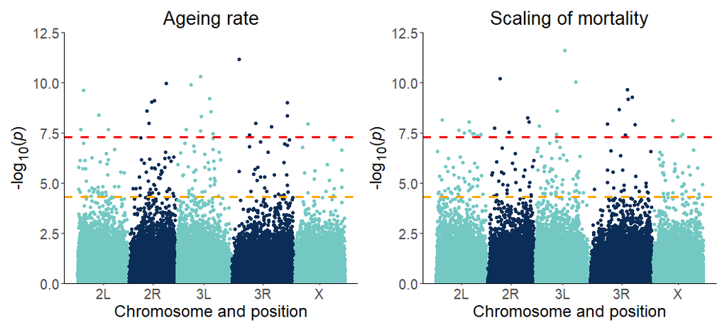

```r
ageing_axis_results <-
  ageing_axis_meta_results %>%
  dplyr::select(SNP, meta_p_hom, meta_p_het) %>%
  rename(P = meta_p_het)

scaling_axis_results <-
  scaling_axis_meta_results %>%
  dplyr::select(SNP, meta_p_hom, meta_p_het) %>%
  rename(P = meta_p_het)

# plot the results using the manhattan plot custom function we defined earlier

ageing_axis_het_plot <-
  build_manhattan_plot(ageing_axis_results) +
  labs(title = "Ageing rate") +
  theme(plot.title = element_text(size = 20, hjust = 0.5)) +
  coord_cartesian(ylim = c(0, 12.5))

scaling_axis_het_plot <-
  build_manhattan_plot(scaling_axis_results) +
  labs(title = "Scaling of mortality") +
  theme(plot.title = element_text(size = 20, hjust = 0.5)) +
  coord_cartesian(ylim = c(0, 12.5))

ageing_axis_het_plot + scaling_axis_het_plot
```

Plot the univariate effect sizes for each of the SNPs associated with the rate of ageing at the genome-wide significance threshold (p < $0.05^{-8}$) after CPASSOC.

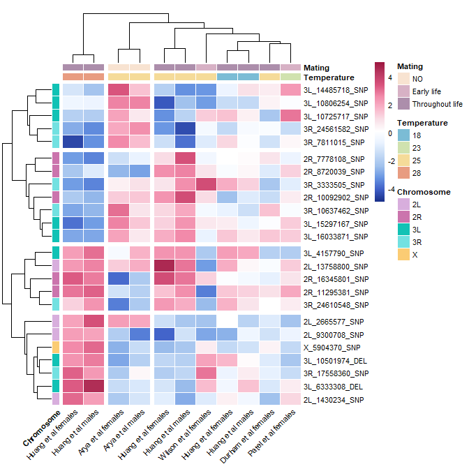

```r
SNP_heatmap_ageing_axis <-
  ageing_axis_meta_results %>% filter(meta_p_het < 0.00000005) %>%
  arrange(meta_p_het) %>% dplyr::select(1:12)

row_name <- SNP_heatmap_ageing_axis$SNP
SNP_heatmap_ageing_axis <- SNP_heatmap_ageing_axis %>% dplyr::select(-SNP) %>% as.matrix()
rownames(SNP_heatmap_ageing_axis) <- row_name

breaksList <- seq(-5, 5, by = 0.1)

annotation_SNPs <-
  ageing_axis_meta_results %>% filter(meta_p_het < 0.00000005) %>% dplyr::select(SNP) %>%
  mutate(Chromosome = case_when(str_detect(SNP, "2L") ~ "2L",
                                str_detect(SNP, "2R") ~ "2R",
                                str_detect(SNP, "3L") ~ "3L",
                                str_detect(SNP, "3R") ~ "3R",
                                str_detect(SNP, "X") ~ "X"))

annotation_studies <-
  tibble(Study = c("Arya_f",
                   "Arya_m",
                   "Huang_f_18",
                   "Huang_m_18",
                   "Huang_f_25",
                   "Huang_m_25",
                   "Huang_f_28",
                   "Huang_m_28",
                   "Wilson_f_25",
                   "Durham_f_25",
                   "Patel_f_23"),
         Temperature = c("25",
                         "25",
                         "18",
                         "18",
                         "25",
                         "25",
                         "28",
                         "28",
                         "25",
                         "25",
                         "23")) %>%
  mutate(Sex = case_when(str_detect(Study, "_f") ~ "Female",
                         .default = "Male"),
         Mating  = case_when(str_detect(Study, "Arya") ~ "NO",
                             str_detect(Study, "Huang") ~ "Throughout life",
                             str_detect(Study, "Wilson") ~ "Early life",
                             str_detect(Study, "Durham") ~ "Throughout life",
                             str_detect(Study, "Patel") ~ "Early life"),
         Author = str_extract(Study, ".*(?=\\_)"),
         Author = str_remove(Author, "_f"),
         Author = str_remove(Author, "_m"))


# create a study annotation column, need this to be a data.frame rather than a tibble for some reason

Study_details <- annotation_studies %>%
  as.data.frame() %>%
  dplyr::select(Study, Temperature, Mating)

my_categories <- data.frame(row.names = Study_details[, 1], Temperature = Study_details[, 2],
                            Mating = Study_details[, 3])

my_colors <- list(Temperature = c("18" = "#7bbcd5", # sailboat colours from pnw
                                  "23" = "#d0e2af",
                                  "25" = "#f5db99",
                                  "28" = "#e89c81"),
                  Mating = c("NO" = "#f8e3d1", # Shuksan from pnw
                             "Early life" = "#d7b1c5",
                             "Throughout life" = "#ac8eab"),
                  Chromosome = c("2L" = "#d8aedd", # lake colours from pnw
                                 "2R" = "#cb74ad",
                                 "3L" = "#11c2b5",
                                 "3R" = "#72e1e1",
                                 "X" = "#fbcc74"))
# create a SNP annotation column

SNP_details <- annotation_SNPs %>%
  as.data.frame()

my_SNP_categories <- data.frame(row.names = SNP_details[, 1], Chromosome = SNP_details[, 2])

my_col_names <- c("Arya et al females", "Arya et al males", "Huang et al females",
                  "Huang et al males", "Huang et al females", "Huang et al males",
                  "Huang et al females", "Huang et al males", "Wilson et al females",
                  "Durham et al females","Patel et al females")


pheatmap(SNP_heatmap_ageing_axis, breaks = breaksList,
         main = "", legend_labels = c("-1", "-0.5", "0", "0.5", "Genetic correlation\n"),
         color = colorRampPalette(rev(met.brewer("Benedictus", direction = 1)))(length(breaksList)),
         legend = TRUE, cutree_rows = 4, cutree_cols = 3,
         angle_col = 45, border_color = "white",
         annotation_col = my_categories, annotation_colors = my_colors, annotation_row = my_SNP_categories,
         fontsize = 8, labels_col = my_col_names)
```

Plot the univariate effect sizes for each of the SNPs associated with the scaling of mortality risk at the genome-wide significance threshold (p < $0.05^{-8}$) after CPASSOC.

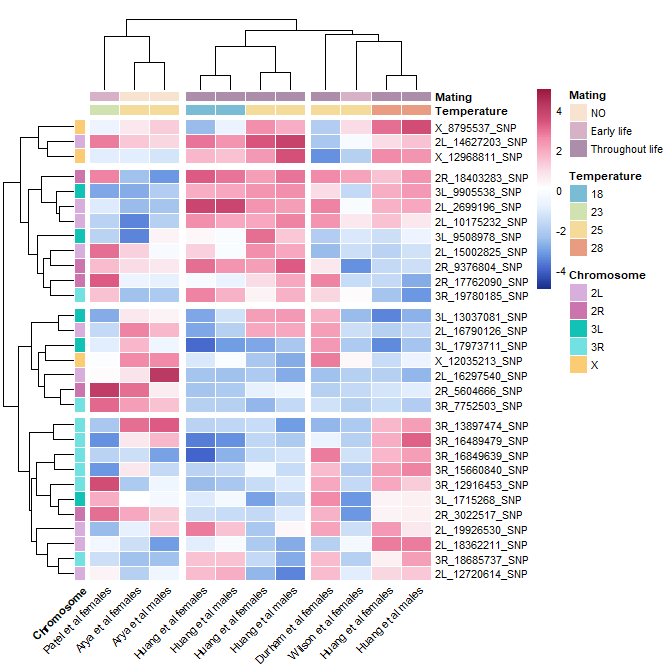

```r
SNP_heatmap_scaling_axis <-
  scaling_axis_meta_results %>% filter(meta_p_het < 0.00000005) %>%
  arrange(meta_p_het) %>% dplyr::select(1:12)

row_name <- SNP_heatmap_scaling_axis$SNP
SNP_heatmap_scaling_axis <- SNP_heatmap_scaling_axis %>% dplyr::select(-SNP) %>% as.matrix()
rownames(SNP_heatmap_scaling_axis) <- row_name

breaksList <- seq(-5, 5, by = 0.1)

annotation_SNPs <-
  scaling_axis_meta_results %>% filter(meta_p_het < 0.00000005) %>% dplyr::select(SNP) %>%
  mutate(Chromosome = case_when(str_detect(SNP, "2L") ~ "2L",
                                str_detect(SNP, "2R") ~ "2R",
                                str_detect(SNP, "3L") ~ "3L",
                                str_detect(SNP, "3R") ~ "3R",
                                str_detect(SNP, "X") ~ "X"))

annotation_studies <-
  tibble(Study = c("Arya_f",
                   "Arya_m",
                   "Huang_f_18",
                   "Huang_m_18",
                   "Huang_f_25",
                   "Huang_m_25",
                   "Huang_f_28",
                   "Huang_m_28",
                   "Wilson_f_25",
                   "Durham_f_25",
                   "Patel_f_23"),
         Temperature = c("25",
                         "25",
                         "18",
                         "18",
                         "25",
                         "25",
                         "28",
                         "28",
                         "25",
                         "25",
                         "23")) %>%
  mutate(Sex = case_when(str_detect(Study, "_f") ~ "Female",
                         .default = "Male"),
         Mating  = case_when(str_detect(Study, "Arya") ~ "NO",
                             str_detect(Study, "Huang") ~ "Throughout life",
                             str_detect(Study, "Wilson") ~ "Early life",
                             str_detect(Study, "Durham") ~ "Throughout life",
                             str_detect(Study, "Patel") ~ "Early life"),
         Author = str_extract(Study, ".*(?=\\_)"),
         Author = str_remove(Author, "_f"),
         Author = str_remove(Author, "_m"))


# create a study annotation column, need this to be a data.frame rather than a tibble for some reason

Study_details <- annotation_studies %>%
  as.data.frame() %>%
  dplyr::select(Study, Temperature, Mating)

my_categories <- data.frame(row.names = Study_details[, 1], Temperature = Study_details[, 2],
                            Mating = Study_details[, 3])

my_colors <- list(Temperature = c("18" = "#7bbcd5", # sailboat colours from pnw
                                  "23" = "#d0e2af",
                                  "25" = "#f5db99",
                                  "28" = "#e89c81"),
                  Mating = c("NO" = "#f8e3d1", # Shuksan from pnw
                             "Early life" = "#d7b1c5",
                             "Throughout life" = "#ac8eab"),
                  Chromosome = c("2L" = "#d8aedd", # lake colours from pnw
                                 "2R" = "#cb74ad",
                                 "3L" = "#11c2b5",
                                 "3R" = "#72e1e1",
                                 "X" = "#fbcc74"))
# create a SNP annotation column

SNP_details <- annotation_SNPs %>%
  as.data.frame()

my_SNP_categories <- data.frame(row.names = SNP_details[, 1], Chromosome = SNP_details[, 2])

my_col_names <- c("Arya et al females", "Arya et al males", "Huang et al females",
                  "Huang et al males", "Huang et al females", "Huang et al males",
                  "Huang et al females", "Huang et al males", "Wilson et al females",
                  "Durham et al females","Patel et al females")


pheatmap(SNP_heatmap_scaling_axis, breaks = breaksList,
         main = "", legend_labels = c("-1", "-0.5", "0", "0.5", "Genetic correlation\n"),
         color = colorRampPalette(rev(met.brewer("Benedictus", direction = 1)))(length(breaksList)),
         legend = TRUE, cutree_rows = 4, cutree_cols = 3,
         angle_col = 45, border_color = "white",
         annotation_col = my_categories, annotation_colors = my_colors, annotation_row = my_SNP_categories,
         fontsize = 8, labels_col = my_col_names)
```

Note that there is a cluster of SNPs found close together on the right arm of chromosome 3 with similar effect sizes across environments. All fall within the range of the common cosmopolitan In(3R)P *Payne* inversion, which is carried by 10 DGRP lines.